# Supplement S1: Description of Climate Vulnerability Indicators for Salmon

08 August 2026

# Overview

This document provides detailed descriptions of the indicators included within Climate Vulnerability Indicators for Salmon (CVIS) framework. For each indicator information is provided according to the following template:

**Metric:** Description of the quantitative method for calculating the indicator.

**Explanation:** Description of the rationale for including the indicator and the climate vulnerability mechanism that it is intended to represent. Includes examples of other studies where the metric has been applied or validated (e.g. through simulation modelling).

**Information Source:** Description of the models or studies used to derive the indicator, including the climate model and spatial or life history datasets used for sub-setting and calculating statistics.

**Standardization Method:** Description of the standardization function applied to the raw indicator values to represent risk on a scale from 0 to 1. Includes explanation of mechanistic or other rationale for the choice of function if relevant.

**Limitations:** Description of known limitations or areas for improvement of the indicator.

**Default scenario output:** Compilation of plots showing the raw and standardized indicator scores and standardization function across all CUs results from the default scenario. For environmental change indicators, the default scenario consists of emissions scenario RCP 4.5, the mid-century time period (2041-2060), and an ensemble mean across available global climate models.

# S.1 Projected August stream temperature (tw8proj)

**Metric:** The average of August stream temperatures across all years of the projection period (2041-2060 or 2081-2100) over all accessible streams with modelled habitat potential contained in the conservation unit (CU) boundary. Streams are weighted by stream segment length when calculating the average value. Projections from representative concentration pathways (RCP) 4.5 and 8.5 are included with an ensemble mean calculated from six global climate models.

**Explanation:** August mean stream temperature is widely used as an index of stream thermal regimes and is strongly correlated with other temperature metrics, such as average spring and fall temperatures (Isaak et al. 2018; Isaak and Young 2023; Iacarella et al. 2024). Temperature data for August is most widely available compared to other times of the year, meaning that these models have the most empirical support compared to other time periods (Isaak et al. 2017; Weller et al. 2024). This time of year is also when stream temperatures peak, therefore representing the most thermally stressful period for many aquatic species.

For Pacific salmon, high stream temperatures in August may impact rearing juveniles present in streams, particularly Chinook and Coho salmon with a yearling life history, through both acute mortality and indirect stress. Although modelled temperatures rarely exceed physiological limits for juvenile survival (Iacarella et al. 2024), elevated temperatures can reduce available habitat, limit growth, productivity and refuge opportunities, and impair function such as aerobic scope (Mantua et al. 2010; Mayer et al. 2023). For other salmon species and life histories, August stream temperatures may not be directly encountered during rearing, but are correlated with high temperatures during adjacent time periods. Therefore, the indicator provides a metric of thermal stress that may apply for rearing and spawning in other months. The negative consequences of high temperatures for these life stages are varied but well-established. For example, elevated temperatures encountered by spawners in late summer and early fall may cause delayed spawning (McCullough et al. 2001), higher pre-spawn mortality (Bowerman et al. 2018), increased susceptibility to pathogens, and reduced spawning success (Richter and Kolmes 2005).

**Information Source:** Projected temperatures are taken from stream thermalscapes scenarios, a statistical stream temperature model fitted to 680,000 km of the BC stream network at approximately 400m intervals (Weller et al. 2024). The model produces temperature predictions averaged over 20-year periods from 1981-2100 using covariates that included catchment area, elevation, glacial cover, air temperature, and precipitation fitted to August mean temperatures from 562 stations in BC. Temporal covariates were taken from six CMIP5-era global climate models. Final model performance was assessed using 10-fold cross-validation and resulted in an R<sup>2</sup> of 0.79 and RMSE of 1.53 C. Streams with catchment areas below 1km2 were not modelled, however, these represent only a small fraction of accessible streams with modelled habitat potential for Pacific salmon.

**Standardization Method:** Projected temperatures are standardized from 0-1 using a scaled exponential normalization increasing from a lower threshold of 15°C according to the formula:

$$z_{i} = \frac{e^{\lambda \frac{x_{i} -
Q_{0.025}}{Q_{0.975} - Q_{0.025}}} - e^{\lambda}}{e^{\lambda} -
e^{-\lambda}}$$

Where $z_{i}$ is the normalized value, $x_{i}$ is the original value, $Q_{0.975}$ is the 97.5<sup>th</sup> quantile value, $Q_{0.025}$ is the 2.5<sup>th</sup> quantile value, and $\lambda$ is a scaling parameter used to control the curvature. For this indicator $Q_{0.025}$ was set to 15, and $\lambda$ was set to 3. An exponential function was used to reflect the expectation of non-linear scaling in risk as temperatures approach higher values that are less suitable for Pacific salmon.

Using this function, any CUs where the average projected August mean temperature was below 15°C had a standardized risk value of 0, representing the expectation of relatively low risk due to projected stream temperatures. The lower threshold of 15°C was selected in consideration of other literature reviews, studies, and water quality guidelines for Pacific salmon. Guidelines and reviews from the US Pacific Northwest and British Columbia suggest optimal temperatures for spawning, rearing, and egg incubation below 16°C (Oliver and Fidler 2001; U.S. Environmental Protection Agency 2003). These guidelines are based on a weekly 7-day average of daily maximum (7DADM) temperatures and maximum weekly average temperatures (MWAT), which could easily exceed the August mean temperature during hot periods. Therefore a lower threshold of 15°C was used for the August mean temperature.

**Limitations:** The indicator’s relevance varies across salmon species and life histories. While August temperatures are directly experienced by stream-type Chinook and Coho salmon rearing as juveniles, they serve primarily as an index of thermal stress during adjacent time periods for other species. In addition, most CUs of sockeye salmon in the Fraser basin rear in lakes, whose temperatures are not modelled. Habitat suitability for rearing sockeye salmon would be better represented by physical and ecological models for lakes that consider factors such as stratification, trophic state, and oxygenation.

The stream temperature model relies on statistical relationships between air temperature, precipitation and observed stream temperatures up to the present, but predictions are more uncertain when extrapolating to temperatures beyond those observed. Broad-scale models may not capture fine-scale thermal heterogeneity important for salmon behavior, and the monthly averaging obscures daily temperature fluctuations and extreme events that can cause acute mortality (Iacarella et al. 2024). The 15°C standardization threshold represents a generalized guideline that may not reflect variation among species, populations, and life stages in thermal optima.

### Default scenario output

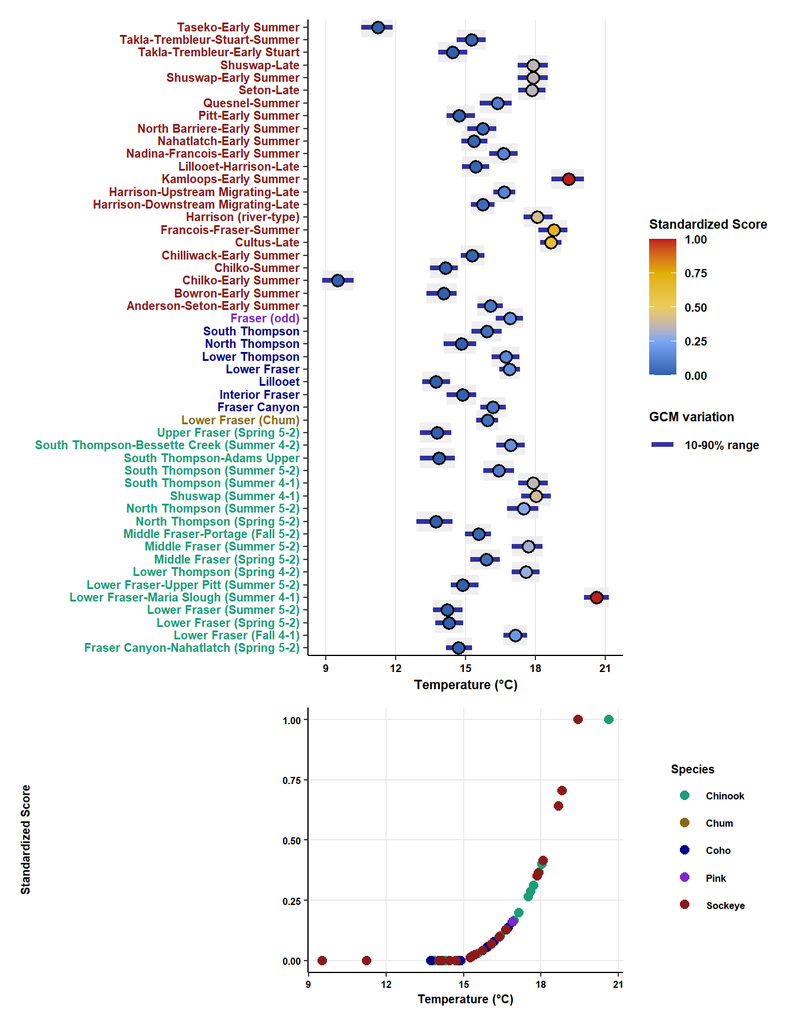

**Fig. S1.1.** Projected August stream temperature (tw8proj) under the default scenario with 80% range of values across GCMs shown by blue bars. The top panel shows raw values for Fraser River CUs, with dot colours representing the standardized value. The bottom panel shows the standardization function curve and mapping of raw to standardized values coloured by species.

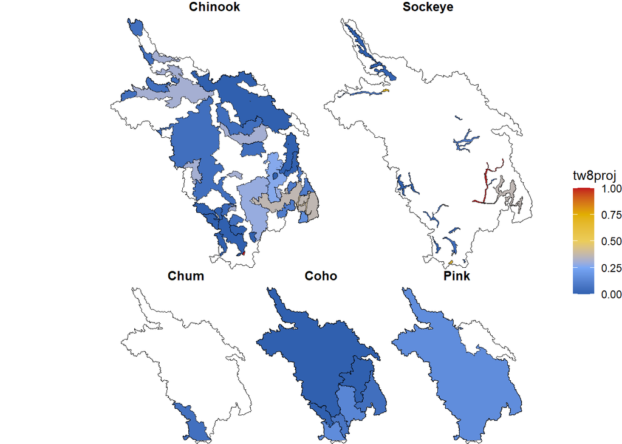

**Fig. S1.2.** Geographic distribution of projected August stream temperature (tw8proj) scores across Fraser River basin CUs.

# S.2 Rate of increase in August stream temperature (tw8rate)

**Metric:** The decadal rate of increase in August mean stream temperature from a baseline period of 1981-2000 to the projection period (2041-2060 or 2081-2100) averaged over all accessible streams with modelled habitat potential contained in the CU boundary. Streams are weighted by stream segment length when calculating the average value. Projections from RCP 4.5 and 8.5 are included with an ensemble mean calculated from six global climate models.

**Explanation**: The rate of climatic warming is a fundamental component for evaluating species exposure to climate changes and is closely related to metrics such as climate velocity and time of climate emergence (Sunday et al. 2012; Brito-Morales et al. 2018; Boyce et al. 2022). Faster rates of warming are more likely to outpace a species’ ability to adapt or migrate, allow less time until exceedance of thermal thresholds or safety margins, and cause greater ecosystem disruption (Comte and Olden 2017; Morley et al. 2019; Boyce et al. 2022). August stream temperatures are a widely used index of stream thermal regime and the rate of temperature increase during this period indicate potential changes to the thermal regime and increases in thermal stress.

For Pacific salmon, the thermal regime within a watershed influences spawning and emergence timing, metabolic rates and growth, hydrology, and ecosystem composition. Warmer temperatures reduce incubation times for eggs, leading to earlier emergence and potential mismatches with primary productivity and optimal food availability, which may not shift at the same pace or extent (Healey 2011; Weinheimer et al. 2017). Higher temperatures may increase juvenile growth and productivity in streams and lakes, particularly for populations at higher latitudes and elevations (Schindler et al. 2005; Gallagher et al. 2022), but this will only favour populations where juveniles are able to adapt with higher growth rates and is contingent upon food availability matching with phenology (Crozier et al. 2008). Greater warming may also favour the invasion of nonnative predators and competitors, such as smallmouth bass, which are predicted to expand with warmer stream temperatures (Lawrence et al. 2014).

The life history and phenology of each CU is adapted to historical conditions and most likely to correspond with the optimal fitness timing for each life-history event (Crozier et al. 2008). As stream temperatures warm, the current equilibrium may be disrupted favouring shifts in timing that may be complementary or divergent across life history events. Ultimately, faster rates of warming limit the amount of time for evolutionary responses, increasing the likelihood of negative consequences to survival.

**Information Source:** Projected and baseline temperatures are taken from stream thermalscapes scenarios (Weller et al. 2024), as described previously for the projected august stream temperature indicator.

**Standardization Method:** The rate of increase in August stream temperature is standardized using a linear normalization function according to the formula:

$$z_{i} = \frac{x_{i} -
Q_{0.025}}{Q_{0.975} - Q_{0.025}}$$

Where $z_{i}$ is the normalized value, $x_{i}$ is the original value, $Q_{0.975}$ is the 97.5<sup>th</sup> quantile value, and $Q_{0.025}$ is the 2.5<sup>th</sup> quantile value of the original data range. The 95% quantile range was used instead of minimum and maximum values to reduce the influence of outliers when normalizing.

**Limitations:** See limitations described for tw8proj.

### Default scenario output

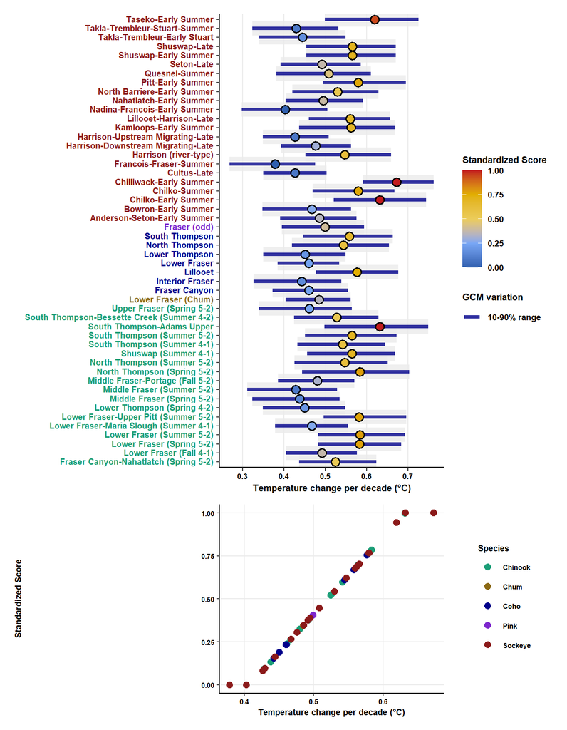

**Fig. S1.3.** Decadal rate of increase in August stream temperature (tw8rate). The top panel shows values across all Fraser River basin Conservation Units (CUs), and the bottom panel shows the standardization function curve.

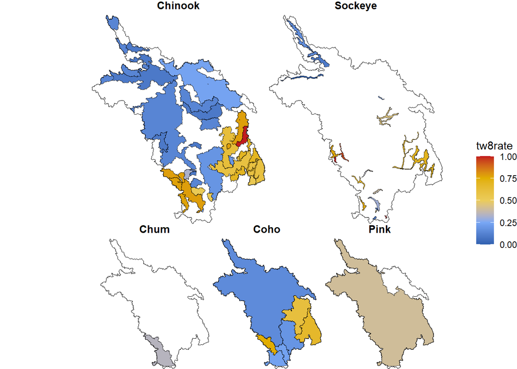

**Fig. S1.4.** Geographic distribution of decadal rate of increase in August stream temperature (tw8rate) scores across Fraser River basin CUs.

# S.3 Proportional decrease in August flows (flow8pdelta)

**Metric:** The change in average August flow from a baseline period of 1981-2010 to the projection period (2041-2060 or 2081-2100), expressed as a proportion of the average historical flow and averaged over all accessible streams with modelled habitat potential contained in the CU boundary. Streams are weighted by stream segment length when calculating the average value. Projections from RCP 4.5 and 8.5 are included with an ensemble mean calculated from six global climate models.

**Explanation:** Pacific salmon require adequate flow during their freshwater life history to migrate and access habitats, provide foraging and refuge opportunities, and sustain water quality. Reduced summer flows and drought may affect Pacific salmon through a variety of mechanisms such as reducing the amount of useable habitat and connectivity among habitats (Tonina et al. 2022), exacerbating thermal stress during high temperature periods (Vehanen et al. 2023), reducing growth by decreasing food availability (Obedzinski et al. 2018), reducing water quality and lowering dissolved oxygen concentration, and causing mortality due to stranding (Warren et al. 2015). Although empirical relationships between low flows and salmon survival are not widely established compared to relationships with temperature, decreases in summer flows have been associated with reduced productivity for multiple populations of stream-type Chinook (Connor et al. 2003; Crozier and Zabel 2006; Warkentin et al. 2022) and reduced coho salmon survival (Obedzinski et al. 2018). We focus on August flows as it represents one of the lowest flow months for many streams within BC and the month with the strongest drying trend over the last half century (Ruzzante and Gleeson 2025). The proportional change in August flows provides an indication of the future drying trend for streams within a CU boundary.

**Information Source:** Model outputs for this indicator are based on the models used by Iacarella et al. 2025 in development of geospatial indicators of stream cumulative threats within the Fraser River basin. Flows were first derived from the Pacific Climate Impacts Consortium (PCIC) Variable Infiltration Capacity with Glaciers (VIC-GL) model, a process-based macroscale hydrology model that projects daily stream temperature and runoff on a gridded resolution of 1/16° (approx. 30 km2) within gauged watersheds of BC (Schnorbus et al. 2024). The VIC-GL model simulates the full water and energy balance including snowpack accumulation and melt, evapotranspiration, soil moisture dynamics, and a module that accounts for glacier retreat under warming temperatures. The gridded model predictions were then downscaled and mapped on to the FWA stream network at a monthly resolution using a model that included the VIC-GL runoff values in combination with average precipitation values for each watershed unit within the Fraser River basin (Iacarella et al. 2025).

**Standardization Method:** The standardized value for the proportional decrease in August flows is obtained using an exponential decay normalization according to the formula:

$$z_{i} = e^{-\lambda \frac{x_{i} -
Q_{0.025}}{Q_{0.975} - Q_{0.025}}} - e^{-\lambda} \frac{x_{i} -
Q_{0.025}}{Q_{0.975} - Q_{0.025}}$$

Where $z_{i}$ is the normalized value, $x_{i}$ is the original value, $Q_{0.975}$ is the 97.5<sup>th</sup> quantile value, $Q_{0.025}$ is the 2.5<sup>th</sup> quantile value, and $\lambda$ is a scaling parameter used to control the curvature. For this indicator $\lambda$ was set to 3, and $Q_{0.975}$ was set to 0 so that risk increased according to the decay function for any changes in flow below 0. An exponential normalization reflects the expectation that vulnerability scaled non-linearly with decreases in August flows, with watersheds that experience the greatest decreases in flow more exposed to drought risk and negative impacts.

**Limitations:** The indicator’s interpretation varies across salmon species and their diverse life histories. Stream-type Chinook salmon that rear in freshwater for one or more years are highly sensitive to summer low flows, which limit available rearing habitat and foraging opportunities during critical growth periods (Connor et al. 2003; Crozier and Zabel 2006). Coho salmon similarly depend on adequate summer flows to maintain pool habitat and connectivity to off-channel refugia (Obedzinski et al. 2018). Other species and life histories may be affected if low flows prevent or impede access to spawning grounds, or lead to reduced spawning success or habitat availability, however, there is less empirical evidence of a relationship between low flows and productivity.

The VIC-GL hydrological model’s performance in simulating low flows is generally weaker than for annual discharge, as macroscale models often struggle to accurately represent groundwater contributions and small-scale hydrological features that maintain summer flows (Wenger et al. 2010). The PCIC VIC-GL model was parameterized using static land cover and forest cover based on observations from 2010. However, logging and wildfires have reduced forest cover since then, and further changes in forest cover and composition will occur over the coming decades. The model does not account for future changes in water withdrawals, land use, or forestry practices that could further alter flow regimes.

### Default scenario output

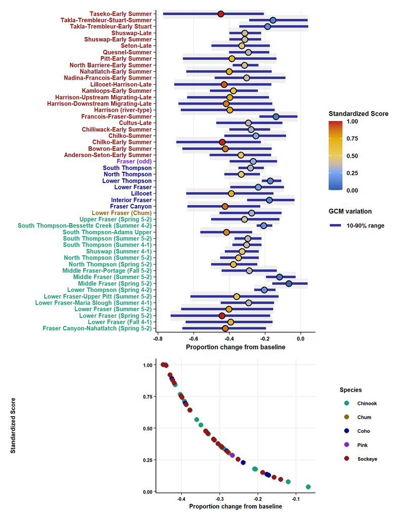

**Fig. S1.5.** Proportional decrease in August flows (flow8pdelta). The top panel shows raw and standardized values across all Fraser River basin Conservation Units (CUs), and the bottom panel shows the standardization function curve.

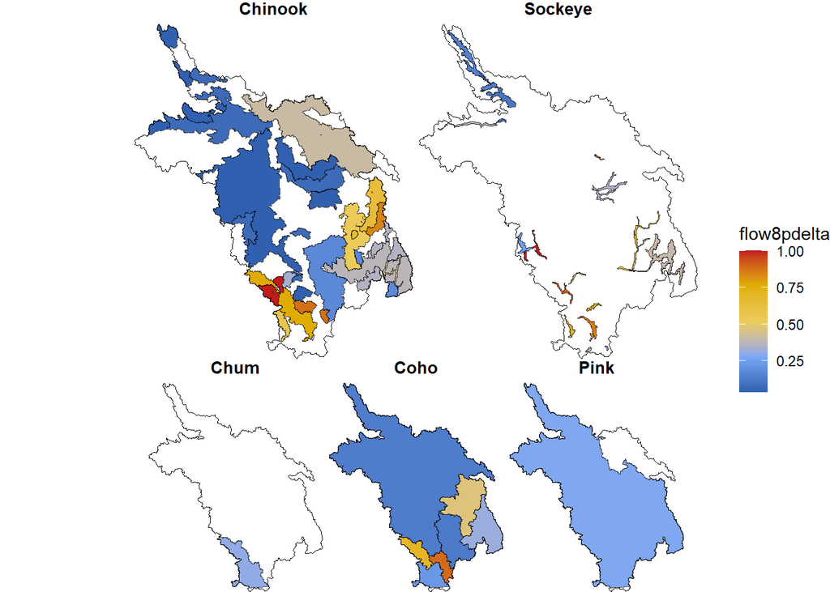

**Fig. S1.6.** Geographic distribution of proportional decrease in August flows (flow8pdelta) scores across Fraser River basin CUs.

# S.4 Proportional increase in November to January flows (flow18pdelta)

**Metric:** The change in average flow for the months of November, December and January from a baseline period of 1981-2010 to the projection period (2041-2060 or 2081-2100), expressed as a proportion of the average historical flow and averaged over all accessible streams with modelled habitat potential contained in the CU boundary. Streams are weighted by stream segment length when calculating the average value. Projections from RCP 4.5 and 8.5 are included with an ensemble mean calculated from six global climate models.

**Explanation:** Elevated flows during the November to January period represents the risk of increased redd scour, a well-known cause of recruitment failure for salmon populations. High flows can mobilize streambed substrates, physically dislodging eggs from redds or burying them under fine sediments (Montgomery et al. 1996; Goode et al. 2013). Empirical studies have linked high flow events to reduced productivity in certain populations (Weinheimer et al. 2017; Anderson and Topping 2018), including Chinook salmon in the Nicola River within the Fraser basin (Warkentin et al. 2022)

Climate change is expected to increase both the magnitude and frequency of extreme precipitation events in coastal BC, creating the potential for more frequent scour events. Models for other regions show potentially severe effects on survival and recruitment under future high flow scenarios (Battin et al. 2007; Shanley and Albert 2014), although impacts will depend on channel morphology, stream gradient, substrate composition, and the rate of changes in flow (Montgomery et al. 1996; Goode et al. 2013).

**Information Source:** Model outputs for this indicator are based on the same approach and models used by Iacarella et al. 2025 and described earlier for the August flow indicator.

**Standardization Method:** The standardized value for the proportional increase in November to January flows is obtained using a scaled exponential normalization according to the formula:
$$z_{i} = \frac{e^{\lambda \frac{x_{i} -
Q_{0.025}}{Q_{0.975} - Q_{0.025}}} - e^{\lambda}}{e^{\lambda} -
e^{-\lambda}}$$

Where $z_{i}$ is the normalized value, $x_{i}$ is the original value, $Q_{0.975}$ is the 97.5<sup>th</sup> quantile value, $Q_{0.025}$ is the 2.5<sup>th</sup> quantile value, and $\lambda$ is a scaling parameter used to control the curvature. For this indicator $Q_{0.025}$ was set to 0, and $\lambda$ was set to 3. The standardization reflects the expectation that scour risk increases non-linearly with flow magnitude, as greater increases are more likely to exceed critical bed mobilization thresholds and cause substantial egg mortality (Goode et al. 2013).

**Limitations:** The indicator is not based on an estimation of frequency of high flow events, but rather the increase in mean flows during November to January period. The monthly resolution of the modelled flows may not capture extreme flow events that are most likely to cause redd scour. Channel morphology and the condition of riparian and upslope vegetation also play important roles in moderating responses to extreme flow events that are not represented by this indicator. The downscaling of GCM precipitation, particularly for extreme events, introduces additional uncertainty as GCMs have limited skill in reproducing the intensity and spatial patterns of atmospheric rivers and other precipitation extremes that dominate winter flooding in coastal BC (Werner and Cannon 2016).

Although there is a substantial volume of evidence demonstrating a relationship between higher winter stream flow and salmon productivity, it has not been demonstrated across all species and the risk caused by redd scour may vary across species and life history types. The time period during which high flows may be more likely to cause redd scour and increase mortality may vary by watershed and peak flow periods generally occur during the spring months. However, we chose to focus on winter flows as egg incubation for almost all CUs occurs during this time.

### Default scenario output

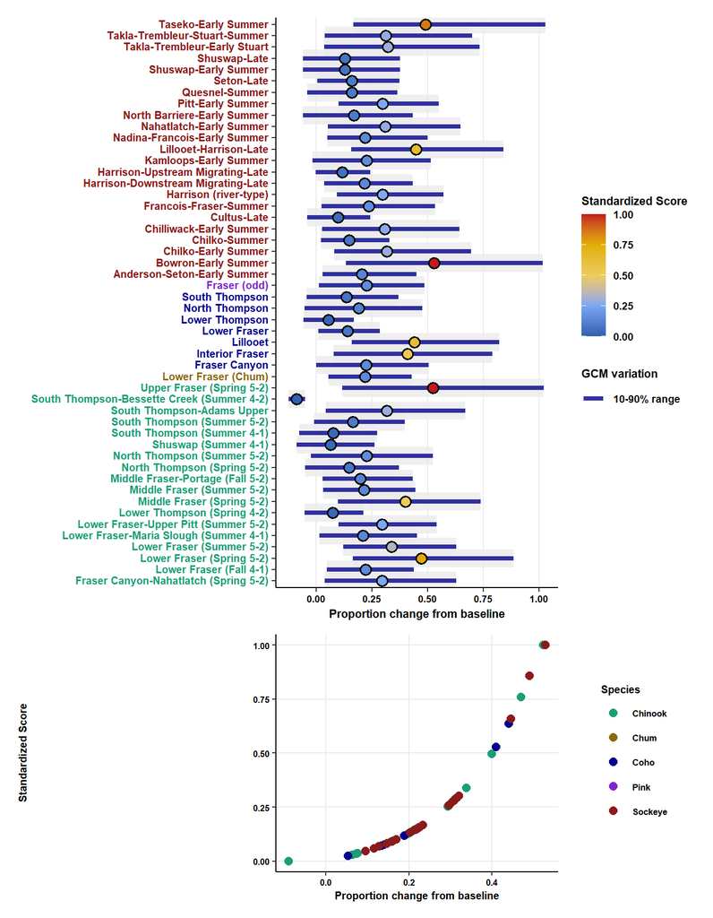

**Fig. S1.7.** Proportional increase in November to January flows (flow18pdelta). The top panel shows raw and standardized values across all Fraser River basin Conservation Units (CUs), and the bottom panel shows the standardization function curve.

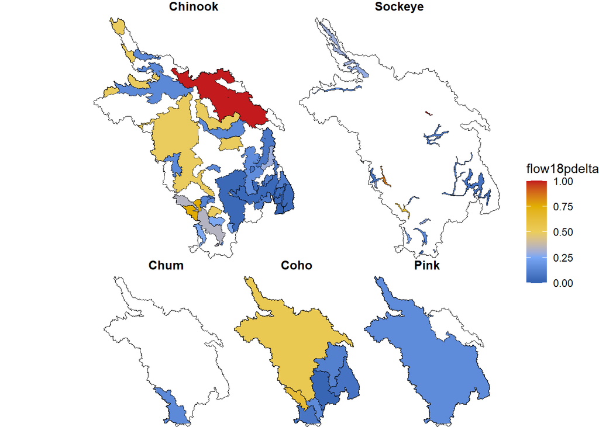

**Fig. S1.8.** Geographic distribution of proportional increase in November to January flows (flow18pdelta) scores across Fraser River basin CUs.

# S.5 Ecological Niche Model change in habitat favourability (favchange)

**Metric:** The change in habitat favourability from the baseline period (1981-2000) to the projection period (2041-2060 or 2081-2100), calculated as the difference between future and baseline favourability values and averaged over all accessible streams within the CU boundary. Habitat favourability is derived from environmental niche models (ENMs) fitted to salmon occurrence data and environmental predictors, providing a metric of environmental suitability that ranges from 0 to 1. The future favourability values use an ensemble mean of six GCMs from RCP 4.5 and 8.5 scenarios for the environmental predictors.

**Explanation:** ENMs quantify the relationship between species distributions and environmental conditions, projecting how climate change may alter habitat suitability across landscapes and over time (Pacifici et al. 2015; Foden et al. 2019). ENMs can identify regions where climate change is expected to improve habitat conditions versus areas where deteriorating conditions may reduce population viability. By comparing current and future habitat favourability for spawning and natal rearing, this indicator captures the net effect of multiple environmental changes on these life stages, accounting for shifts in August stream temperature and annual precipitation.

**Information Source:** Favourability predictions were applied from ENMs for the spawning ranges of the five Pacific salmon species across BC, as described in Iacarella and Weller 2023. Environmental predictor variables included August stream temperature, annual precipitation, distance to ocean, and proximity to lakes (for sockeye only). Models were fitted separately for each species and a generalized boosted model was selected as the best model following cross-validation among five different model types. A baseline period of 1981-2020 was used for all model fitting, with projected August stream temperature and precipitation from 2021-2100 derived over 20 year time periods from six different GCMs.

**Standardization Method:** Changes in habitat favourability are standardized using an inverted linear normalization according to the formula:
$$z_{i} = 1 -
\frac{x_{i} - Q_{0.025}}{Q_{0.975} - Q_{0.025}}$$

Where $z_{i}$ is the normalized value, $x_{i}$ is the original value, $Q_{0.975}$ is the 97.5<sup>th</sup> quantile value, and $Q_{0.025}$ is the 2.5<sup>th</sup> quantile value of the original data range. For this indicator $Q_{0.975}$ was set to 0 so that any positive changes in favourability were assigned a risk score of 0.

**Limitations:** Projections to future conditions may require extrapolation into non-analog climates—combinations of environmental variables not present during the training period. The models do not account for potential evolutionary adaptation or rapid phenotypic plasticity that could maintain population persistence despite environmental change, nor do they incorporate demographic processes (dispersal, metapopulation dynamics) or biotic interactions (predation, competition, disease) that mediate climate impacts. ENM predictions should be interpreted within the context that (1) habitat occupancy is limited by other factors, (2) salmon must be able to migrate to and from these areas, and (3) extreme events from climate change are not captured by these models (Iacarella and Weller 2023).

### Default scenario output

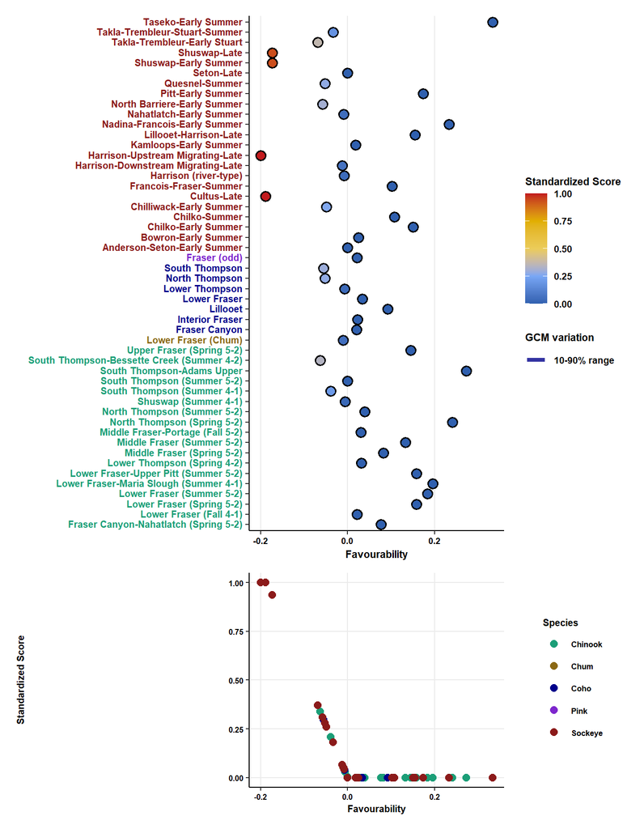

**Fig. S1.9.** Ecological Niche Model change in habitat favourability (favchange). The top panel shows raw and standardized values across all Fraser River basin Conservation Units (CUs), and the bottom panel shows the standardization function curve.

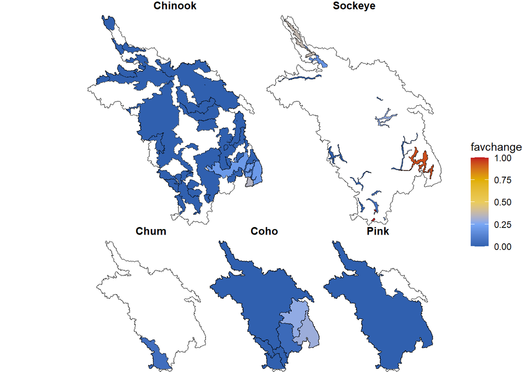

**Fig. S1.10.** Geographic distribution of Ecological Niche Model change in habitat favourability (favchange) scores across Fraser River basin CUs.

# S.6 Cumulative threats to stream habitat (cthr)

**Metric:** A composite index of threats from human activity to stream habitat, calculated using a normalized additive model that combines nine threat categories including flow alteration, in-stream habitat destruction, riparian disturbance, nutrients, pollution, and sedimentation. The indicator is calculated as the mean cumulative threat score across all accessible streams with modelled habitat potential in the CU boundary, weighted by stream segment length.

**Explanation:** Climate change does not occur in isolation but rather compounds existing anthropogenic stressors on salmon habitat, creating cumulative impacts that can push populations beyond thresholds for persistence. Habitat status is a commonly included factor in climate change vulnerability assessments and often associated with species sensitivity to climate change (Wade et al. 2013; Crozier et al. 2019; Foden et al. 2019). Stream habitats that are already in a degraded state have reduced resilience to absorb climate-driven changes in temperature, flow, and other properties (Beechie et al. 2013). The cumulative threats score for spawning and rearing streams within CU boundaries provides a metric of pre-existing watershed impairment that contextualizes sensitivity to environmental changes represented by other indicators.

**Information Source:** Cumulative threat scores were adapted from those described by Iacarella et al. 2025 and incorporate information from multiple federal and provincial databases with spatial coverage across all streams within the Fraser River basin. For some threat categories, particularly longitudinal fragmentation (passage barriers), the cumulative threat model uses distinct methods for anadromous versus resident species but only the anadromous species threat score was included in the indicator. All threat categories were included in the indicator score, recognizing that while some categories may be more important than others in determining habitat sensitivity to climate change all of them may contribute to some extent.

**Standardization Method:** The cumulative threat score is standardized using a linear normalization according to the formula:
$$z_{i} = \frac{x_{i} - Q_{0.025}}{Q_{0.975}
- Q_{0.025}}$$

**Limitations:** The cumulative threats index assumes that stressors to stream habitats combine linearly and independently, and that this additive score represents stream sensitivity to environmental changes. In reality, the relationship between anthropogenic stressors on stream habitat and the ability of that habitat to support salmon and remain resilient to climate change is complex and non-linear. Other limitations and assumptions of the cumulative threats model are described in Iacarella et al. 2025.

The indicator’s interpretation requires consideration of species-specific threat sensitivities and life history vulnerabilities. Stream-type Chinook and Coho salmon that rear in tributaries for over a year are directly exposed to the full range of instream and riparian threats, making cumulative threat scores highly relevant to these life histories, while other species and life histories may only be vulnerable to a subset of threat categories. The threat categories only represent streams and therefore do not quantify the condition of lake rearing habitats for sockeye. The CU-level averaging of threat scores obscures within-CU variation in habitat quality, which may be critical for persistence if high-quality refugia enable subpopulation persistence despite widespread habitat degradation.

### Default scenario output

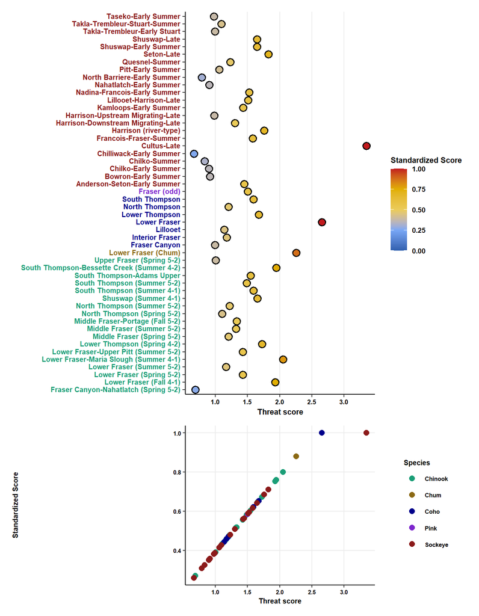

**Fig. S1.11.** Cumulative threats to stream habitat (cthr). The top panel shows raw and standardized values across all Fraser River basin Conservation Units (CUs), and the bottom panel shows the standardization function curve.

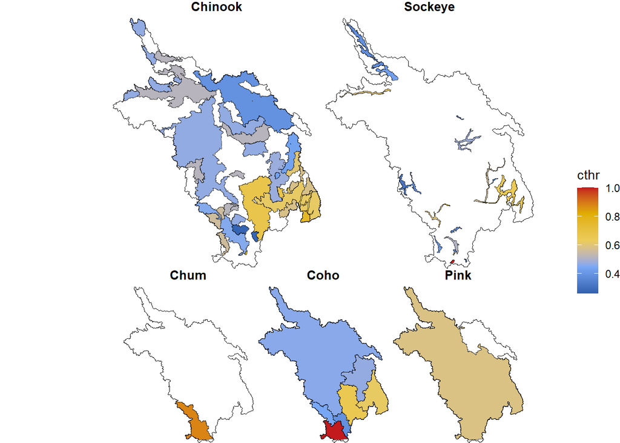

**Fig. S1.12.** Geographic distribution of cumulative threats to stream habitat (cthr) scores across Fraser River basin CUs.

# S.7 Freshwater residency time (fwres)

**Metric:** The duration in days that juvenile salmon reside in freshwater from the start of egg incubation to ocean entry. For each CU, residency time is calculated using as the number of days from peak spawn timing to peak ocean entry timing, plus the typical number of years spent in freshwater (0 or 1).

**Explanation:** Freshwater residency time is an integrative life history trait that determines the cumulative exposure to freshwater climate stressors (temperature, flow, habitat availability). While the climate vulnerability implications of residency duration are complex and context-dependent, there is ample evidence that CUs with longer freshwater residency are more sensitive to environmental changes in freshwater habitats. The freshwater residency time indicator provides a simple metric to differentiate life history types among CUs and assess sensitivity to future changes based on their temporal exposure within freshwater.

**Information Source:** Freshwater residency time is derived from a life history timing data set for Pacific salmon CUs across their Canadian range, as described in Wilson and Peacock 2025. The repository incorporates multiple data sources to characterize timing by life stage across regions and species. For spawn timing, the estimates are based primarily upon New Spawning Escapement Database (NuSEDS) data collected by aerial surveys, stream walks, and weir counts. For ocean entry timing, estimates use various collection methods including incline plane traps, rotary screw traps, weirs, and fyke nets, though most estimates for Fraser CUs are based on the lower Fraser river incline plane and rotary screw traps. Data quality estimates are provided for each CU representing the recentness and number of sites or observations for each CU.

**Standardization Method:** The freshwater residency indicator is scored using a step-function that divides residency days into three categories: immediate migrants with residency times less than 200 days, sub-yearlings with residency times greater than 200 days but less than 300 days, and yearlings with residency times greater than 300 days. Immediate migrants, which are restricted to pink and chum salmon CUs, are assigned a standardized value of 0, while sub-yearlings and yearlings were assigned values of 0.5 and 1, respectively.

**Limitations:** Data quality varies by life stage and species, with estimates of ocean entry timing generally being more uncertain than spawn timing, and estimates for most sockeye CUs being higher quality than other species (Wilson and Peacock 2025). Populations with variation in freshwater residency times and life history stategies may not be adequately represented by a single residency metric, but diversity in life history strategies may be an important factor in determining adaptive capacity. The freshwater residency indicator assumes that residency duration remains relatively constant under climate change, yet there is substantial evidence that the timing of life history transitions within freshwater exhibit phenotypic plasticity and may respond adaptively to changing conditions (Crozier et al. 2008).

Many factors mediate the sensitivity of Pacific salmon to environmental change within freshwater that are not represented by a simple metric of residency time. Disentangling the sensitivity of populations to different factors is difficult without information on survival by life stage and life cycle models (Crozier et al. 2021). We assume a monotonic relationship between freshwater residency time and climate vulnerability, however, “optimal” residency depends on the relative severity of freshwater versus marine stressors, which varies across areas and may shift as climate change progresses. Freshwater habitats that are resilient to climate changes or increase in habitat favourability with warming could serve as refuges that sustain local salmon productivity and favour life histories with longer residency times, particularly if marine conditions are poor.

### Default scenario output

[figure not shown]

**Fig. S1.13.** Freshwater residency time (fwres). The top panel shows raw and standardized values across all Fraser River basin Conservation Units (CUs), and the bottom panel shows the standardization function curve.

# S.8 Projected temperature during upstream migration (migrTproj)

**Metric:** The average of water temperatures during the upstream migration across all years of the projection period (2041-2060 or 2081-2100) estimated along the migration path from river entry to spawning sites using an upstream migration model. The model uses a moving migration window to represent the thermal exposure of CUs starting at the river mouth on the run timing start date and terminating at spawning sites on the peak spawning date. Projections from representative concentration pathways (RCP) 4.5 and 8.5 are included with an ensemble mean calculated from six global climate models.

**Explanation:** Higher temperatures can negatively affect salmon during their upstream migration through a variety of mechanisms including acute mortality due to exceedance of critical thermal limits, creation of thermal barriers that delay spawning, greater disease susceptibility, higher pre-spawn mortality, and reduced aerobic scope (McCullough et al. 2001; Martins et al. 2011; Bowerman et al. 2018; Mayer et al. 2023). Within the Fraser basin, where some populations migrate over 1000 kilometres upstream, mortality and reduced spawning success from higher river temperatures have been extensively studied and modelled (Crossin et al. 2004; Farrell et al. 2008; Eliason et al. 2011), and are used annually by fisheries managers to adjust escapement targets for Fraser sockeye in order to compensate for increased mortality during high temperature conditions (Patterson et al. 2016). Mortality is generally not equal across sexes, with observed mortality two times higher for females than males (Hinch et al. 2021). The average projected migration temperature provides an indication of the indirect and direct negative consequences of future temperatures and exceedance of thermal limits for salmon CUs.

**Information Source:** Projected water temperatures were taken from gridded outputs of the PCIC VIC-GL model (Schnorbus et al. 2024). The VIC-GL model generates projections of water temperature and flow for each day of the year from 1951-2100, which were averaged over the projection periods. The model grid was intersected with the upstream migration path within the stream network to subset cells when averaging temperature. River entry and spawn timing for each CU were taken from the same life history timing data set used to assess freshwater residency time (Wilson and Peacock 2025) and used to determine start and end dates for the upstream migration model. The location of spawning sites, representing the terminal ends of migration paths, were taken from NuSEDS observations for each CU. Sites with old and intermittent observations were removed by filtering sites with less than 5 observations and where the most recent observation was older than 2010.

**Standardization Method:** Projected temperatures are standardized from 0-1 using a scaled exponential normalization increasing from a lower threshold of 15°C according to the formula:
$$z_{i} = \frac{e^{\lambda \frac{x_{i} -
Q_{0.025}}{Q_{0.975} - Q_{0.025}}} - e^{\lambda}}{e^{\lambda} -
e^{-\lambda}}$$

Where $z_{i}$ is the normalized value, $x_{i}$ is the original value, $Q_{0.975}$ is the 97.5<sup>th</sup> quantile value, $Q_{0.025}$ is the 2.5<sup>th</sup> quantile value, and $\lambda$ is a scaling parameter used to control the curvature. For this indicator $Q_{0.025}$ was set to 15, and $\lambda$ was set to 3. For this indicator $Q_{0.025}$ was set to 15, and $\lambda$ was set to 3.

Any CUs where the projected temperature during upstream migration was below 15°C had a standardized risk value of 0, representing the expectation of relatively low risk. The lower threshold of 15°C corresponds with the optimal temperature for aerobic scope of Fraser sockeye (Eliason et al. 2011), and is a lower limit beyond which increases in mortality associated with temperature may be observed (Martins et al. 2011; Atlas et al. 2021). There is limited evidence of negative temperature impacts on aerobic scope or migration below 15°C, even for populations of coho salmon that typically experience much lower migration temperatures (Raby et al. 2016). An exponential function was used for standardization reflecting the expectation that risks of mortality and sub-lethal impacts increase non-linearly with temperature.

**Limitations:** The upstream migration model assumes a uniform rate of migration from river mouth to spawning sites with the first arrival to spawning sites coinciding with spawn timing start. In reality, migration speeds may be variable and some CUs may utilize cold-water refuges or hold in lakes along their upstream migration. The indicator does not consider cold-water refuges, which can decrease exposure to sub-lethal thermal stress and be particularly important in maintaining the viability of summer-run timing phenotypes (Snyder et al. 2022). The migration model uses a fixed river entry and spawn timing for CUs based on historical observations, but shifts in run and spawn timing can occur in response to natural and anthropogenic pressures (Kovach et al. 2012; Crozier and Siegel 2025).

### Default scenario output

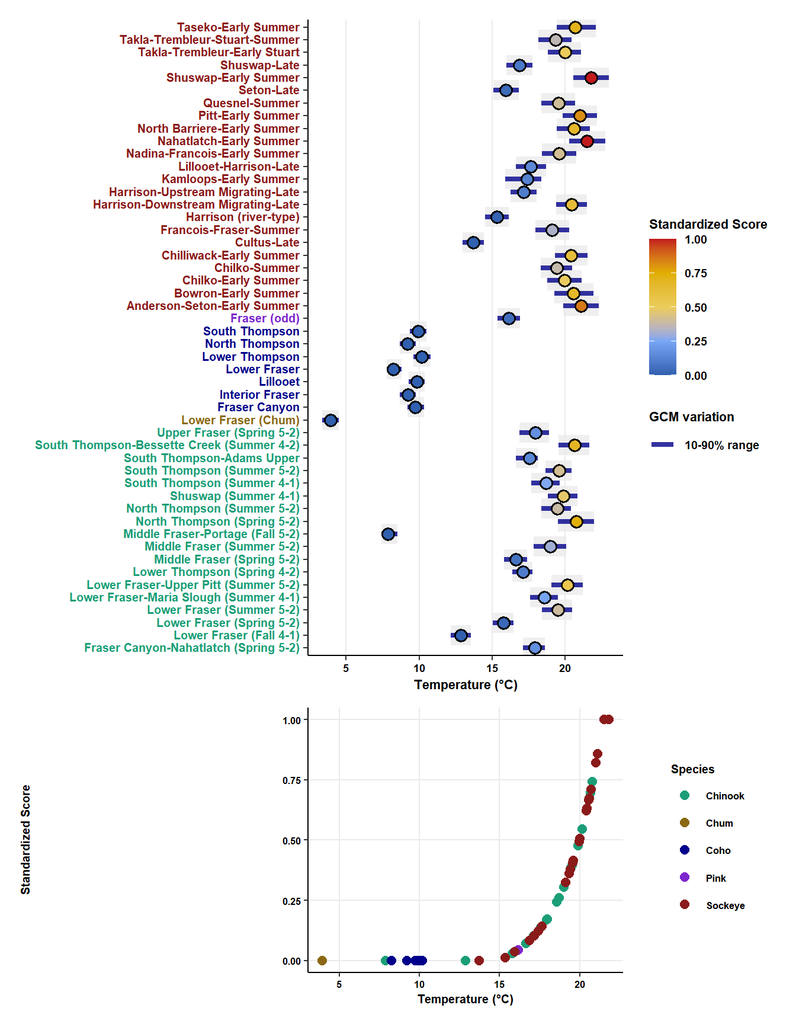

**Fig. S1.14.** Projected temperature during upstream migration (migrTproj). The top panel shows raw and standardized values across all Fraser River basin Conservation Units (CUs), and the bottom panel shows the standardization function curve.

# S.9 Proportional change in flow during upstream migration (migrQpdelta)

**Metric:** The proportional change in flow during the upstream migration from the baseline period (1981-2000) to the projection period (2041-2060 or 2081-2100) estimated along the migration path from river entry to spawning sites using an upstream migration model. The model uses a moving migration window to represent the average flow experienced by CUs starting at the river mouth on the run timing start date and terminating at spawning sites on the peak spawning date. Projections from representative concentration pathways (RCP) 4.5 and 8.5 are included with an ensemble mean calculated from six global climate models.

**Explanation:** Both high and low flows can create barriers to salmon migrating to spawning grounds and impact their condition through direct effects on swimming energetics and interacting effects of flow and temperature. The effects of high and low flows vary based on the watershed type and on CU migration life history. In large river systems like the Fraser, high flows increase the energetic costs of swimming, slowing down the speed of migrating salmon and potentially creating velocity barriers in river reaches with constricted banks like the Fraser Canyon (Rand et al. 2006). This pattern seems to be the opposite in smaller watersheds where lower flows are a particular challenge as they may create passage barriers that reduce access to spawning habitats, exacerbate effects of increased temperatures, and delay migration (Atlas et al. 2021).

**Information Source:** Projected water temperatures were taken from gridded outputs of the PCIC VIC-GL model (Schnorbus et al. 2024). The VIC-GL model generates projections of water temperature and flow for each day of the year from 1951-2100, which were averaged over the projection periods. The model grid was intersected with the upstream migration path within the stream network to subset cells when averaging temperature.

### Default scenario output

[figure not shown]

**Fig. S1.15.** Proportional change in flow during upstream migration (migrQpdelta). The top panel shows raw and standardized values across all Fraser River basin Conservation Units (CUs), and the bottom panel shows the standardization function curve.

# S.10 Upstream migration distance (migrdist)

**Metric:** The distance of the migration path from river mouth to spawning sites. For CUs with multiple spawning locations, the average of the migration distance to all spawning sites is used.

**Explanation:** Migration distance represents a simple metric of the difficulty and energetic requirements for upstream migration, the most energetically demanding phase of the salmon life cycle. The energetic costs of migration scale with distance as adults cease feeding prior to freshwater entry and rely on stored lipids and proteins for all metabolic demands during migration, gonadal development, and spawning. Longer upstream migrations impose greater energetic demands, are more likely to expose populations to higher temperatures or thermal barriers, and require more specialized adaptation to overcome (Farrell et al. 2008; Eliason et al. 2011). While populations that undergo difficult, longer migrations have adaptations that allow them to survive and spawn successfully, such as higher lipid stores, fewer eggs, and smaller, more fusiform morphologies (Crossin et al. 2004), such adaptations reflect evolutionary trade-offs whose consequences may become more severe with further warming (Crozier et al. 2008).

**Information Source:** The location of spawning sites, representing the terminal ends of migration paths, were taken from NuSEDS observations for each CU. Sites with old and intermittent observations were removed by filtering sites with less than 5 observations and where the most recent observation was older than 2010. Migration paths were created from the stream network within the Freshwater Atlas (FWA) based on downstream segment distances and watershed codes.

**Standardization Method:** Upstream migration distance is standardized using a linear normalization according to the formula:
$$z_{i} = \frac{x_{i} - Q_{0.025}}{Q_{0.975}
- Q_{0.025}}$$

Where $z_{i}$ is the normalized value, $x_{i}$ is the original value, $Q_{0.975}$ is the 97.5<sup>th</sup> quantile value, and $Q_{0.025}$ is the 2.5<sup>th</sup> quantile value of the original data range. A simple linear function was adopted reflecting the proportional scaling of energy requirements with migration distance. The 2.5th and 97.5th percentile values were used instead of the minimum and maximum values to avoid undue influence from CUs with extreme values.

**Limitations:** The indicator treats all kilometers equally, but migration path heterogeneity can impose highly variable energetic costs and create velocity or elevation barriers to migration (e.g. Hell’s Gate in the Fraser Canyon). Migration difficulty and energetic requirements depend on temperature and flow, which are assessed separately.

### Default scenario output

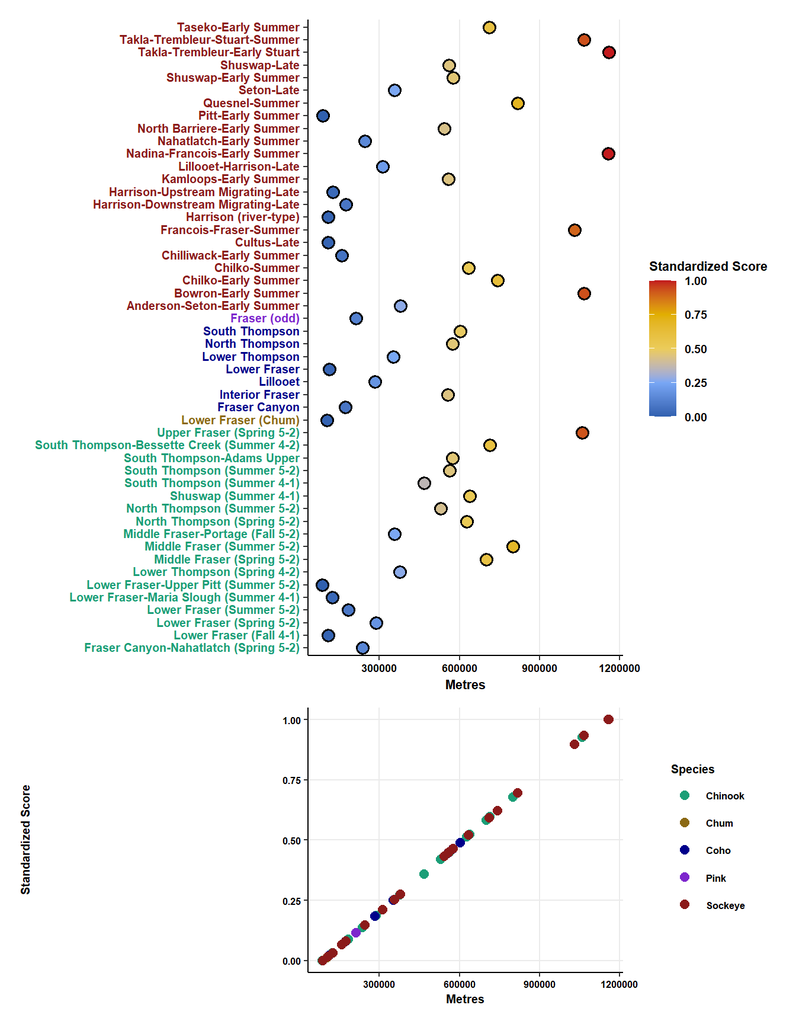

**Fig. S1.16.** Upstream migration distance (migrdist). The top panel shows raw and standardized values across all Fraser River basin Conservation Units (CUs), and the bottom panel shows the standardization function curve.

# S.11 Projected nearshore sea surface temperature (SSTproj)

**Metric:** The projected sea surface temperature (SST) across all years of the projection period (2041-2060 or 2081-2100) throughout the marine adaptive zone (MAZ) for the CU averaged from the months of April to July, corresponding to the entry and early marine residence period for most stocks in southern B.C Projections from RCP 4.5 and 8.5 are included with an ensemble mean calculated from 28 global climate models.

**Explanation:** Nearshore marine SST is a critical environmental variable for Pacific salmon that influences growth and survival by determining prey availability and quality, ecosystem composition, metabolic demands, and habitat selection. During warmer years, shifts in zooplankton composition to species with lower nutritional value are well documented within the southern range of Pacific salmon (Mackas et al. 2007; Fergusson et al. 2020). Warmer SST may also increase competition and put Pacific salmon at a competitive disadvantage with other species such as juvenile sablefish (Daly et al. 2024). Direct physiological effects from elevated temperatures in marine areas are more difficult to isolate and prove, but higher temperatures result in higher metabolic rates and energy requirements (Beauchamp et al. 2007; Daly and Brodeur 2015), and influence depth and swimming behaviour (Ueno 1992; Sabal et al. 2023).

At regional scales, SST trends and anomalies is one of the most important variables for explaining patterns of salmon productivity, with higher SSTs consistently associated with lower survival and productivity across populations and particularly those in southern BC and the continental United States (Mueter et al. 2002; Sharma et al. 2013; Kilduff et al. 2014). For BC salmon, high SSTs from marine heatwaves, particularly the Blob, have been associated with poor productivity (Grant et al. 2019) and models have linked SST anomalies with reduced recruitment (Connors et al. 2020). By representing the future SST that salmon will experience during their entry into the ocean, this indicator provides a metric of climate exposure that can be compared across regions and relative to the historical baseline. This metric shares properties with other indicators of climate risk used for marine species, such as thermal safety margins and time of climate emergence (Boyce et al. 2022).

**Information Source:** Ensemble mean and quantile ranges for SSTs were derived from 28 global climate models from the CMIP6 suite of models that were bias corrected to a higher resolution using the quantile delta mapping (QDM) method trained on the global Ocean Sea Surface Temperature and Ice Analysis (OSTIA) historical data set (Donlon et al. 2012).

MAZs used to determine SST spatial domains were adapted from those used to define salmon CUs for the Wild Salmon Policy (Holtby and Ciruna 2007). These areas consist of twelve distinct ecoregions for salmon that characterize the nearshore adaptive marine environments for Pacific salmon. MAZ boundaries were slightly modified from those described in Holtby and Ciruna 2007 to correspond with boundaries from corresponding marine biogeographic regions (DFO 2009).

SSTs were compared to dynamically-downscaled, regional oceanographic model projections for validation. For the Georgia Strait MAZ, SSTs were compared to the SalishSeaCast model, developed to represent the complex and distinct oceanographic processes within the Salish Sea (Ridenour and Holdsword, in prep). For other coastal regions of BC, SSTs were compared to the BCCM model surface layer projections, with a mask layer used to exclude regions where conditions could not be adequately represented by the models (Peña and Fine 2024). Both models are dynamically downscaled from the CanESM2 global climate model from CMIP5.

**Standardization Method:** The projected sea surface temperature indicator was standardized using an exponential function parameterized with minimum and maximum values across all MAZs on the British Columbia coast. All CUs in the Fraser basin are within the Strait of Georgia MAZ as they all share a common ocean entry point, therefore the risk score for marine indicators was standardized across all marine adaptive zones in British Columbia to obtain a more informative score for relative risk. An exponential function was used to reflect the expectation of non-linear scaling in risk as temperatures approach higher values that are less suitable for Pacific salmon.

**Limitations:** The mechanisms relating nearshore SST to salmon survival are complex and mediated by ecosystem interactions, oceanography, and life history characteristics, which are not represented by this or other indicators. Projected SST represents a coarse proxy for these underlying dynamics and the underlying relationship with survival and productivity may exhibit non-stationary and non-linear responses over time.

Pacific salmon CUs were associated with marine conditions based on MAZs, a representation of the marine entry and nearshore rearing area for CUs. Within the Fraser Basin, all CUs share the Georgia Strait MAZ, however, nearshore life history strategies are diverse with some marine ecotypes spending longer and variable residency times within Georgia Strait, while others out-migrate further north relatively quickly. The exposure of CUs to changes in nearshore SST may therefore vary, and the consequences for vulnerability are not evaluated. Habitat use, distribution, and depth also vary across marine ecotypes and may determine exposure to warmer temperatures, hypoxic waters, and other negative conditions. Models of fine-scale marine distribution could provide a more detailed and realistic representation of exposure to increased SSTs.

### Default scenario output

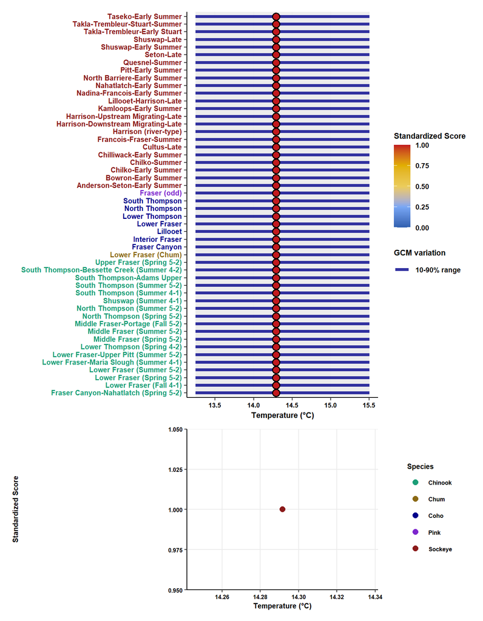

**Fig. S1.17.** Projected nearshore sea surface temperature (SSTproj). The top panel shows raw and standardized values across all Fraser River basin Conservation Units (CUs), and the bottom panel shows the standardization function curve.

# S.12 Rate of increase in nearshore sea surface temperatures (SSTrate)

**Metric:** The decadal rate of increase in SST from a baseline period to the projection period (2041-2060 or 2081-2100) throughout the marine adaptive zone (MAZ) for the CU over a 6-month period beginning with the month prior to ocean entry. Projections from RCP 4.5 and 8.5 are included with an ensemble mean calculated from 28 global climate models.

**Explanation:** The rate of climatic warming is a fundamental component for evaluating species exposure to climate changes and is closely related to metrics such as climate velocity and time of climate emergence (Sunday et al. 2012; Brito-Morales et al. 2018; Boyce et al. 2022). Faster rates of warming are more likely to outpace a species’ ability to adapt or migrate, allow less time until exceedance of thermal thresholds or safety margins, and cause greater ecosystem disruption (Comte and Olden 2017; Morley et al. 2019; Boyce et al. 2022). The rate of increase in nearshore SST represents changes to the marine thermal regime during a period of critical growth and survival for salmon.

**Information Source:** Historical and projected SST values are taken from CMIP6 models bias corrected to a higher resolution using the QDM method as described for the projected nearshore SST indicator.

**Standardization Method:** The rate of increase in sea surface temperature was standardized using a linear function parameterized with minimum and maximum values across all MAZs on the British Columbia coast. All CUs in the Fraser basin are within the Strait of Georgia MAZ as they all share a common ocean entry point, therefore the risk score for marine indicators was standardized across all marine adaptive zones in British Columbia to obtain a more informative score for relative risk.

**Limitations:** As described for the projected nearshore SST indicator, the mechanisms relating the rate of increase in SST to survival and climate change vulnerability are complex and not fully represented by this indicator.

### Default scenario output

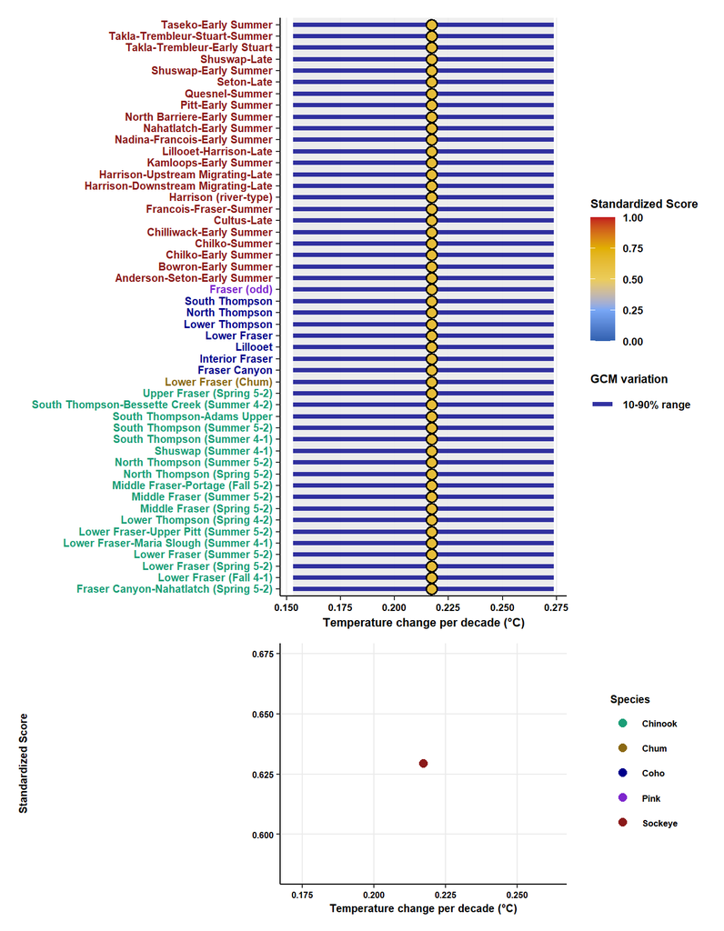

**Fig. S1.18.** Rate of increase in nearshore sea surface temperatures (SSTrate). The top panel shows raw and standardized values across all Fraser River basin Conservation Units (CUs), and the bottom panel shows the standardization function curve.

# S.13 Cumulative impacts to nearshore marine habitat (CImpact)

**Metric:** The average cumulative impact score of nearshore habitats averaged throughout the MAZ for a CU. Cumulative impact scores are calculated for multiple habitat categories within the Pacific region including pelagic, benthic, eelgrass, and kelp forests. Stressors included as part of the additive cumulative impact model include aquaculture, fishing, invasive species, nutrient inputs, pollution inputs, and shipping (Murray et al. 2024).

**Explanation:** Estuarine and nearshore marine environments are important habitats for salmon as they complete smoltification and early marine growth. The cumulative impacts to nearshore marine habitats provides an index of stressors to these habitats that contextualizes sensitivity to environmental changes represented by other indicators. Marine habitats experiencing greater cumulative impacts are more vulnerable to tipping points and synergistic impacts from climate change (Halpern et al. 2008; Boyce et al. 2022).

**Information Source:** This indicator is derived from a cumulative impact model developed for Canadian marine ecosystems (Murray et al. 2024).

**Standardization Method:** The cumulatuve impact score was standardized using a linear function parameterized with minimum and maximum values across all MAZs on the British Columbia coast. All CUs in the Fraser basin are within the Strait of Georgia MAZ as they all share a common ocean entry point, therefore the risk score for marine indicators was standardized across all marine adaptive zones in British Columbia to obtain a more informative score for relative risk. A simple linear function was adopted because the threat score already represents a standardized, additive index.

### Default scenario output

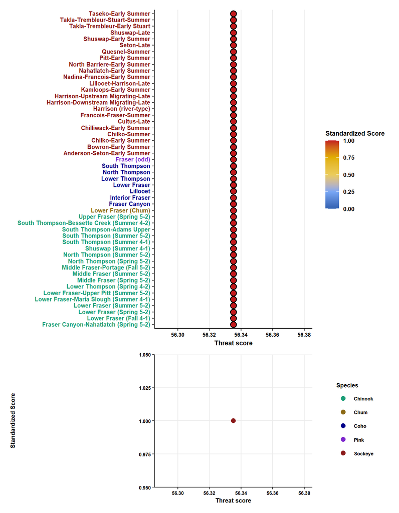

**Fig. S1.19.** Cumulative impacts to nearshore marine habitat (CImpact). The top panel shows raw and standardized values across all Fraser River basin Conservation Units (CUs), and the bottom panel shows the standardization function curve.

# S.14 Conservation status (CUstatus)

**Metric:** Recent Wild Salmon Policy (WSP) conservation status of a CU categorized as either Red, Amber, or Green. Status was assessed using the Rapid Status Assessment Approach that uses a Yes/No decision tree considering the number of recent spawners, trends in abundance, data type (absolute or relative abundance), and biological benchmarks (Pestal et al. 2023; CSAS 2024). The input data, thresholds and appropriate metrics, and final status of Fraser CUs in 2022/2023 were evaluated and agreed upon by expert judgement throughout the Rapid Status process.

**Explanation:** Conservation status is an important metric of climate change sensitivity and adaptive capacity that is often incorporated in vulnerability assessments (Pacifici et al. 2015; Crozier et al. 2019; Foden et al. 2019; Boyce et al. 2022). Status is a comprehensive metric that can represent multiple facets of vulnerability, such as stress already imposed on a species from factors other than climate change, rarity and demographic risk, as well as sensitivity to recent climatic changes. A poor conservation status often indicates that a species is experiencing stress from non-climatic anthropogenic stressors, reducing its resiliency to further changes and catastrophic events.

For Pacific salmon CUs, conservation status reflects the recent and historical influence of multiple stressors across marine and freshwater habitats, as well as the inherent size and extent of a CU. Smaller CUs with lower abundances are more likely to be assigned a red status because the assessment method uses a minimum abundance threshold of 1,500 spawners measured against the CUs generational geometric mean.

**Information Source:** WSP status evaluations of Fraser CUs were conducted in 2023 and 2024 using the Rapid Status Assessment Approach, which uses a decision tree interpreted and agreed upon by expert judgement. Data requirements include spawner abundances from NuSEDS or area-based Stock Assessment programs, stock-recruitment data where available, appropriate escapement sites and years selected by stock assessment experts based on data quality and quantity, and data treatments including gap filling as applicable. The appropriate application of abundance thresholds is assessed and relative-abundance benchmarks may be updated from prior integrated status assessments if updated data or methods are available. Confidence ratings of high, medium, or low are assigned as part of the assessment framework based on the decision tree node used to assign status (i.e. the method for assigning status based on data availability) , which is a corollary of confidence measures from previous integrated status processes. Higher confidence scores were assigned to status designations based on relative and absolute abundance indices rather than trend metrics. For further details on the WSP rapid status method see (Pestal et al. 2023; CSAS 2024).

**Standardization Method:** The status category was converted to a standardized score between 0 and 1 using a simple categorical function. A status of green was assigned a score of 0; amber status was scored as 0.5; and red status was scored as 1.

**Limitations:** The categorical status rating and standardization method are based primarily on generational averages or trends in spawner abundance and do not capture the full range of demographic characteristics that influence population condition and climate vulnerability. Other characteristics such as fecundity, the number and status of sites (populations), spawner size, and spawner age may be exhibiting different trends across CUs that are not evaluated as part of the conservation status indicator. Trends in spawners can only act as a proxy for how other biological process may affect productivity.

Data quality and confidence in the assessment score varies across CUs and is represented by a confidence rating assigned to each status assignment. A few CUs were data-deficient and not able to be assessed.

### Default scenario output

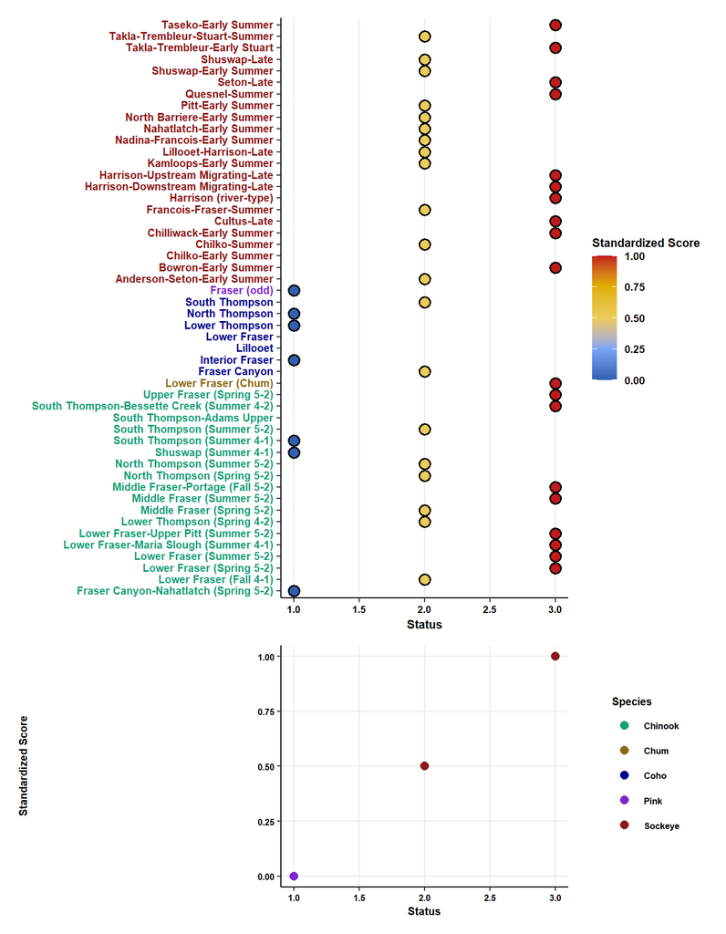

**Fig. S1.20.** Conservation status (CUstatus). The top panel shows raw and standardized values across all Fraser River basin Conservation Units (CUs), and the bottom panel shows the standardization function curve.

# S.15 Recent generational average of natural spawners (CUnmat)

**Metric:** The geometric average of the number of natural-origin spawners (male and female) over the most recent generation with available estimates. Natural-origin spawners are those that are born in the wild but whose parents may or may not be of hatchery origin (DFO 2018). For cyclic sockeye CUs where abundance is dominated by a single-year on the cycle line, the number of spawners from the most recent dominant year is used instead of the average over all years of a generation.

**Explanation:** Ecological theory and empirical evidence shows that larger, healthier populations possess demographic buffers allowing them to better withstand climate and anthropogenic pressures (Pacifici et al. 2015; Foden et al. 2019). Smaller populations are more susceptible to stochastic events, are associated with lower genetic diversity, and have lower resilience to stressors and cumulative threats. The recent generational average of natural spawners represents the higher demographic risk for populations at lower abundances and is an important component of climate change vulnerability (Wade et al. 2013; Pearson et al. 2014).

Only natural-origin spawners were used for the generational average as they are more likely to contribute to population persistence and adaptive capacity compared to hatchery-origin spawners. Natural-origin spawners are also used for status assessments and thresholds for the WSP rapid status assessment method (Pestal et al. 2023).

**Information Source:** The generational average of spawners were taken from the WSP rapid status evaluations of Fraser CUs, as described for the conservation status indicator.

**Standardization Method:** The generational average of spawners was converted to a standardized score between 0 and 1 using an exponential decay function that increased inversely with abundance below a maximum threshold of 10,000 spawners. CUs with more than 10,000 spawners were assigned a score of 0, with the risk value increasing to the maximum score of 1 at 0 spawners. This relationship corresponds to the abundance thresholds used for WSP status assessments and the expectation of risk increasing non-linearly as abundance declines.

**Limitations:** This metric shares similarities with the conservation status indicator, but is focused specifically on recent abundances independent of any trends. For many CUs absolute abundance information that is representative of the entire CU is not available, therefore a relative index was used. Relative indices of abundance are adjusted using an expansion factor, but may nonetheless underestimate the absolute abundance due to potential error associated with the expansion method. In addition, some streams are not consistently surveyed and are not included when determining the relative index of abundance for a CU.

### Default scenario output

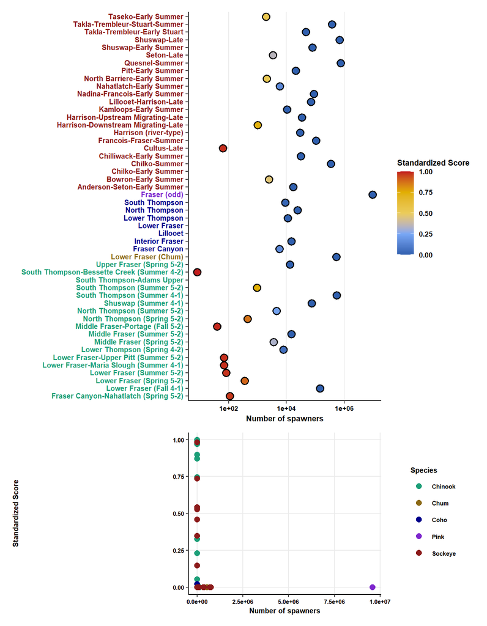

**Fig. S1.21.** Recent generational average of natural spawners (CUnmat). The top panel shows raw and standardized values across all Fraser River basin Conservation Units (CUs), and the bottom panel shows the standardization function curve.

# S.16 Heterozygosity (hetzyg)

**Metric:** Pacific salmon are diploid organisms with two copies of each nuclear chromosome in the genome. Heterozygosity is the proportion of genomic locations that contain a different allele (i.e., variant) on each copy of the chromosome within an individual. To calculate heterozygosity, genotypes are called for each genetic loci from sequencing data, and the number of loci with two variants is divided by the total number of loci in the dataset for each individual. Heterozygosity for a population is then calculated as the average across individuals.

**Explanation:** The impacts of climate change on organisms, in part, depend on the responses of the organisms to those changes. One mechanism through which organisms respond to environmental change is through adaptation. Adaptation as a result of directional selection requires selection to operate on variation that exists within the population. Climate change responses will need to occur over relative short timeframes in the context of evolution, and thus climate change adaptation is unlikely to rely primary on new mutations in a population. Consequently, the raw material that will allow adaptive responses to climate change is the genetic variation that exists in the population currently, which is known as standing genetic variation. Heterozygosity is a metric that provides an estimate of standing genetic variation, and lower heterozygosity within a population suggests lower capacity for adaptive responses (Tigano et al. 2023).

**Information Source:** The heterozygosity values presented in this assessment were determined from low-coverage whole-genome resequencing of Pacific salmon DNA. DNA was isolated from tissue samples, primarily fin, using standard methods and then sequenced on an Illumina NovaSeq X. Approximately 33M PE150 sequencing reads were generated per sample, which were then trimmed to remove adaptor content with fastp, and aligned to a reference genome corresponding to the relevant species with bwa. Alignments were filtered to remove PCR duplicates, and then genotype likelihoods at single-nucleotide polymorphisms (SNPs) were determined with angsd. Genotypes were imputed from the genotype likelihoods with beagle, and heterozygosity values were calculated by the proportion of heterozygous sites out of the total number of SNPs in the dataset.

**Standardization Method:** Heterozygosity is standardized using a linear normalization according to the formula:

Where $z_{i}$ is the normalized value, $x_{i}$ is the original value, $Qs_{0.975}$ is the 97.5<sup>th</sup> quantile value, and $Qs_{0.025}$ is the 2.5<sup>th</sup> quantile value of the original data range within the species only. Measures of heterozygosity are not comparable across species, therefore ranges used for standardization were restricted to observations within the same species. The 2.5th and 97.5th percentile values were used instead of the minimum and maximum values to avoid undue influence from CUs with extreme values.

**Limitations:** Heterozygosity is a common method to estimate standing genetic variation, but it relies upon called genotypes for individuals. For the datasets used here, the numbers of individuals sequenced were sufficient to support imputation of genotypes from the genotype likelihoods. However, this may not always be the case, particularly using low-coverage sequencing data. In such a case, an alternative metric of standing genetic variation could be employed (e.g., nucleotide diversity; (Layton et al. 2021)). Additionally, any estimate of standing genetic variation will be sensitive to the genomic loci that are used to generate the estimate. As a result, heterozygosity values are not directly comparable across different studies or species.

### Default scenario output

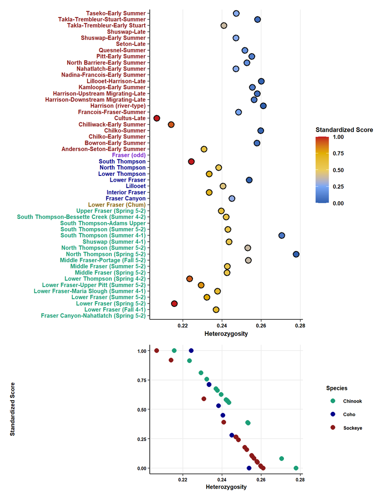

**Fig. S1.22.** Heterozygosity (hetzyg). The top panel shows raw and standardized values across all Fraser River basin Conservation Units (CUs), and the bottom panel shows the standardization function curve.

# S.17 Genomic offset (genoff)

**Metric:** A genomic offset is an estimate of the mismatch between the genetic variation in a population of organisms under current conditions and the genetic variation that would be predicted to track a forecasted change in climate. To determine a genomic offset, first, genotype-environment associations are established using genomic data and environmental data across a species’ current range. Putatively adaptive loci are identified from these associations and then used to model genetic variation among populations as a function of environmental variation (i.e., allelic turnover in response to climate variation). Once this model is established, forecasted environmental conditions under climate change are used as input into the model to predict the genetic variation that would match forecasted climate conditions for a population. The Euclidean distance between a population’s current genetic variation and the predicted variation that would track climate change is the genomic offset.

**Explanation:** A genomic offset reflects how much genetic change would be required for a population to track climate change at a location under the assumption that adaptation will proceed in similar ways to the local environmental adaptation present in the species currently. These estimates provide insights on the relative capacity for adaptation to environmental change among populations as a higher offset suggests that more adaptive genetic change would be required for that population to respond to the impacts of climate change (Layton et al. 2021; Tigano et al. 2023).

**Information Source:** The genomic offsets presented in this assessment were determined from the same low-coverage whole-genome resequencing of Pacific salmon DNA as those used to determine heterozygosity. See the Heterozygosity section above for details on sequence generation and genotype calling. Genotypes were used to calculate population-specific allele frequencies at all SNPs in the dataset for each species, and genotype-environmental associations were determined by redundancy analysis (Capblancq and Forester 2021) using the allele frequencies and environmental data obtained from the WorldClim database (four non-redundant bioclim variables: bio1, bio5, bio15 and bio16). Outlier SNPs consistent with involvement in environmental adaptation were determined by identifying SNPs with loadings on the first three RDA axes that exceeded three standard deviations from the mean of all SNP loadings on the axis. Allele frequencies for the outlier loci were then used as the response variables in a gradient forest model with all 19 bioclim variables as predictors. Genomic offsets were determined by the Euclidean distance between the model fit with current environmental conditions, and the model fit under forecasted conditions for CMIP6 SSP8.5 (no mitigation scenario).

**Standardization Method:** Genomic offset is standardized using a linear normalization according to the formula:
$$z_{i} = \frac{x_{i} -
Qs_{0.025}}{Qs_{0.975} - Qs_{0.025}}$$

Where $z_{i}$ is the normalized value, $x_{i}$ is the original value, and $Qs_{0.025}$ and $Qs_{0.975}$ represent the 2.5<sup>th</sup> quantile and 97.5<sup>th</sup> quantiles within the species’ range of values. Measures of genomic offset are not comparable across species, therefore ranges used for standardization were restricted to observations within the same species. The 2.5th and 97.5th percentile values were used instead of the minimum and maximum values to avoid undue influence from CUs with extreme values.

**Limitations:** Genomic offsets are not a direct estimate of climate change vulnerability, and their predictive capability is highly contextual. For example, in some cases, environmental changes that result in higher genomic offsets can correspond to increases in population fitness, as adaptive states under current conditions may no longer be optimal under novel conditions, but may still experience an overall increase in fitness. Additionally, the gradient forest model fit assumes that current genetic variation and environmental conditions reflect adaptive states, and that future adaptation to climate conditions will reflect adaptative process that have produced extant patterns of variation. However, given what is known about environmental adaptation based on current variation, genomic offsets provide predictions on which populations of a species may require the most genetic change as a result of climate change, which can be considered as a component of estimating risk. Genomic offsets are relative measures that are dependent on the genomic loci considered in the analysis, and are not directly comparable across separate analyses, studies or species.

### Default scenario output

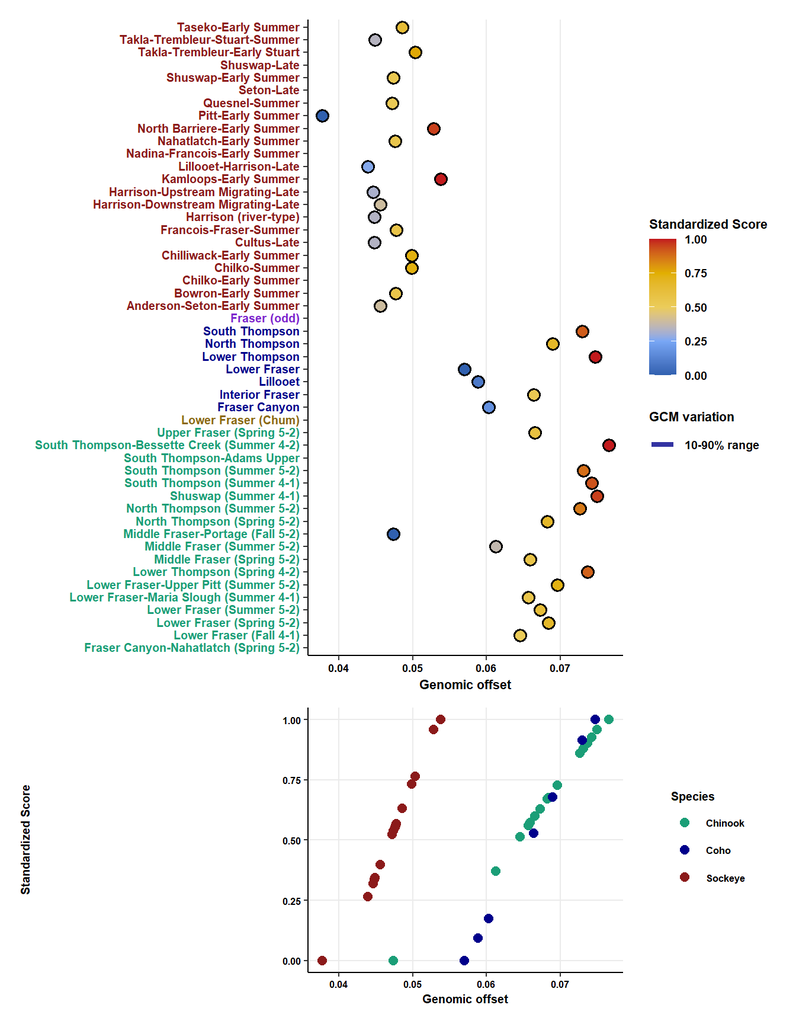

**Fig. S1.23.** Genomic offset (genoff). The top panel shows raw and standardized values across all Fraser River basin Conservation Units (CUs), and the bottom panel shows the standardization function curve.

# Literature Cited

Anderson, J.H., and Topping, P.C. 2018. Juvenile Life History Diversity and Freshwater Productivity of Chinook Salmon in the Green River, Washington. North American Journal of Fisheries Management **38**(1): 180–193. doi:10.1002/nafm.10013.

Atlas, W.I., Seitz, K.M., Jorgenson, J.W.N., Millard-Martin, B., Housty, W.G., Ramos-Espinoza, D., Burnett, N.J., Reid, M., and Moore, J.W. 2021. Thermal sensitivity and flow-mediated migratory delays drive climate risk for coastal sockeye salmon. Facets **6**(1): 71–89. doi:10.1139/FACETS-2020-0027.

Battin, J., Wiley, M.W., Ruckelshaus, M.H., Palmer, R.N., Korb, E., Bartz, K.K., and Imaki, H. 2007. Projected impacts of climate change on salmon habitat restoration. Proceedings of the National Academy of Sciences of the United States of America **104**(16): 6720–6725. doi:10.1073/pnas.0701685104.

Beauchamp, D.A., Cross, A.D., Armstrong, J.L., Myers, K.W., Moss, J.H., Boldt, J.L., and Haldorson, L.J. 2007. Bioenergetic Responses by Pacific Salmon to Climate and Ecosystem Variation. NPAFC Bulletin (4): 257–269.

Beechie, T., Imaki, H., Greene, J., Wade, A., Wu, H., Pess, G., Roni, P., Kimball, J., Stanford, J., Kiffney, P., and Mantua, N. 2013. Restoring salmon habitat for a changing climate. River Research and Applications **29**(8): 939–960. doi:10.1002/rra.2590.

Bowerman, T., Roumasset, A., Keefer, M.L., Sharpe, C.S., and Caudill, C.C. 2018. Prespawn Mortality of Female Chinook Salmon Increases with Water Temperature and Percent Hatchery Origin. Trans Am Fish Soc **147**(1): 31–42. doi:10.1002/tafs.10022.

Boyce, D.G., Tittensor, D.P., Garilao, C., Henson, S., Kaschner, K., Kesner-Reyes, K., Pigot, A., Reyes, R.B., Reygondeau, G., Schleit, K.E., Shackell, N.L., Sorongon-Yap, P., and Worm, B. 2022. A climate risk index for marine life. Nature Climate Change **12**(9): 854–862. Springer. doi:10.1038/s41558-022-01437-y.

Brito-Morales, I., García Molinos, J., Schoeman, D.S., Burrows, M.T., Poloczanska, E.S., Brown, C.J., Ferrier, S., Harwood, T.D., Klein, C.J., McDonald-Madden, E., Moore, P.J., Pandolfi, J.M., Watson, J.E.M., Wenger, A.S., and Richardson, A.J. 2018. Climate Velocity Can Inform Conservation in a Warming World. Trends in Ecology and Evolution **33**(6): 441–457. doi:10.1016/j.tree.2018.03.009.

Capblancq, T., and Forester, B.R. 2021. Redundancy analysis: A Swiss Army Knife for landscape genomics. Methods Ecol Evol **12**(12): 2298–2309. doi:10.1111/2041-210X.13722.

Comte, L., and Olden, J.D. 2017. Climatic vulnerability of the world’s freshwater and marine fishes. Nature Clim Change **7**(10): 718–722. doi:10.1038/nclimate3382.

Connor, W.P., Burge, H.L., Yearsley, J.R., and Bjornn, T.C. 2003. Influence of Flow and Temperature on Survival of Wild Subyearling Fall Chinook Salmon in the Snake River. North American Journal of Fisheries Management **23**(2): 362–375. doi:10.1577/1548-8675(2003)023<0362:IOFATO>2.0.CO;2.

Connors, B., Malick, M.J., Ruggerone, G.T., Rand, P., Adkison, M., Irvine, J.R., Campbell, R., and Gorman, K. 2020. Correction to: Climate and competition influence sockeye salmon population dynamics across the northeast pacific ocean (Can. j. fish. aquat. sci. 77(6): 943–949, 2020, 10.1139/cjfas-2019-0422). Canadian Journal of Fisheries and Aquatic Sciences **77**(12): 1977–1978. doi:10.1139/cjfas-2020-0401.

Crossin, G.T., Hinch, S.G., Farrell, A.P., Higgs, D.A., Lotto, A.G., and Oakes A N D M C Healey, J.D. 2004. Energetics and morphology of sockeye salmon: effects of upriver migratory distance and elevation. Journal of Fish Biology **65**: 788–810. doi:10.1111/j.1095-8649.2004.00486.x.

Crozier, L.G., Burke, B.J., Chasco, B.E., Widener, D.L., and Zabel, R.W. 2021. Climate change threatens Chinook salmon throughout their life cycle. Communications Biology **4**(1). Springer. doi:10.1038/s42003-021-01734-w.

Crozier, L.G., Hendry, A.P., Lawson, P.W., Quinn, T.P., Mantua, N.J., Battin, J., Shaw, R.G., and Huey, R.B. 2008. Potential responses to climate change in organisms with complex life histories: evolution and plasticity in Pacific salmon. Evolutionary Applications **1**(2): 252–270. Wiley. doi:10.1111/j.1752-4571.2008.00033.x.

Crozier, L.G., McClure, M.M., Beechie, T., Bograd, S.J., Boughton, D.A., Carr, M., Cooney, T.D., Dunham, J.B., Greene, C.M., Haltuch, M.A., Hazen, E.L., Holzer, D.M., Huff, D.D., Johnson, R.C., Jordan, C.E., Kaplan, I.C., Lindley, S.T., Mantua, N.J., Moyle, P.B., Myers, J.M., Nelson, M.W., Spence, B.C., Weitkamp, L.A., Williams, T.H., and Willis-Norton, E. 2019. Climate vulnerability assessment for Pacific salmon and steelhead in the California Current Large Marine Ecosystem. PLoS ONE **14**(7). doi:10.1371/journal.pone.0217711.

Crozier, L.G., and Siegel, J.E. 2025. From threats to solutions: A literature review of climate adaptation in anadromous salmon and trout. Ecosphere **16**(1): e70054. doi:10.1002/ecs2.70054.

Crozier, L.G., and Zabel, R.W. 2006. Climate impacts at multiple scales: evidence for differential population responses in juvenile Chinook salmon. Journal of Animal Ecology **75**(5): 1100–1109. doi:10.1111/j.1365-2656.2006.01130.x.

CSAS. 2024. Rapid Status Approximations for Pacific Salmon Derived from Integrated Expert Assessments under Fisheries and Oceans Canada Wild Salmon Policy. **004**.

Daly, E.A., and Brodeur, R.D. 2015. Warming Ocean Conditions Relate to Increased Trophic Requirements of Threatened and Endangered Salmon. PLoS ONE **10**(12): e0144066. doi:10.1371/journal.pone.0144066.

Daly, E.A., Chasco, B.E., Morgan, C.A., Burke, B.J., Osborne, K.E., and Draper, D.L. 2024. Implications of increased spatial and trophic overlap between juvenile Pacific salmon and Sablefish in the northern California Current. Marine and Coastal Fisheries **16**(6): e10325. doi:10.1002/mcf2.10325.

DFO. 2009. Development of a Framework and Principles for the Biogeographic Classification of Canadian Marine Areas. DFO Can. Sci. Advis. Sec. Sci. Advis. Rep **2009/056**.

DFO. 2018. Review of genetically based targets for enhanced contributions to Canadian pacific Chinook Salmon populations. DFO Can. Sci. Advis. Sec. Sci. Advis. Rep. **2018/001**.

Donlon, C.J., Martin, M., Stark, J., Roberts-Jones, J., Fiedler, E., and Wimmer, W. 2012. The Operational Sea Surface Temperature and Sea Ice Analysis (OSTIA) system. Remote Sensing of Environment **116**: 140–158. doi:10.1016/j.rse.2010.10.017.

Eliason, E.J., Clark, T.D., Hague, M.J., Hanson, L.M., Gallagher, Z.S., Jeffries, K.M., Gale, M.K., Patterson, D.A., Hinch, S.G., and Farrell, A.P. 2011. Differences in thermal tolerance among sockeye salmon populations. Science **332**(6025): 109–112. doi:10.1126/science.1199158.

Farrell, A. P., Hinch, S. G., Cooke, S. J., Patterson, D. A., Crossin, G. T., Lapointe, M., and Mathes, M. T. 2008. Pacific Salmon in Hot Water: Applying Aerobic Scope Models and Biotelemetry to Predict the Success of Spawning Migrations. Physiological and Biochemical Zoology **81**(6): 697–709. doi:10.1086/592057.

Fergusson, E., Miller, T., McPhee, M.V., Fugate, C., and Schultz, H. 2020. Trophic responses of juvenile Pacific salmon to warm and cool periods within inside marine waters of Southeast Alaska. Progress in Oceanography **186**: 102378. doi:10.1016/j.pocean.2020.102378.

Foden, W.B., Young, B.E., Akçakaya, H.R., Garcia, R.A., Hoffmann, A.A., Stein, B.A., Thomas, C.D., Wheatley, C.J., Bickford, D., Carr, J.A., Hole, D.G., Martin, T.G., Pacifici, M., Pearce‐Higgins, J.W., Platts, P.J., Visconti, P., Watson, J.E.M., and Huntley, B. 2019. Climate change vulnerability assessment of species. WIREs Climate Change **10**(1): e551. doi:10.1002/wcc.551.

Gallagher, B.K., Geargeoura, S., and Fraser, D.J. 2022. Effects of climate on salmonid productivity: A global meta‐analysis across freshwater ecosystems. Global Change Biology **28**(24): 7250–7269. doi:10.1111/gcb.16446.

Goode, J.R., Buffington, J.M., Tonina, D., Isaak, D.J., Thurow, R.F., Wenger, S., Nagel, D., Luce, C., Tetzlaff, D., and Soulsby, C. 2013. Potential effects of climate change on streambed scour and risks to salmonid survival in snow-dominated mountain basins. Hydrological Processes **27**(5): 750–765. John. doi:10.1002/HYP.9728.

Grant, S.C.H., MacDonald, B.L., and Winston, M.L. 2019. State of Canadian Pacific Salmon: Responses to Changing Climate and Habitats.

Halpern, B.S., McLeod, K.L., Rosenberg, A.A., and Crowder, L.B. 2008. Managing for cumulative impacts in ecosystem-based management through ocean zoning. Ocean & Coastal Management **51**(3): 203–211. doi:10.1016/j.ocecoaman.2007.08.002.

Healey, M. 2011. The cumulative impacts of climate change on Fraser River sockeye salmon ( Oncorhynchus nerka ) and implications for management. Canadian Journal of Fisheries and Aquatic Sciences **68**(4): 718–737. doi:10.1139/f2011-010.

Hinch, S.G., Bett, N.N., Eliason, E.J., Farrell, A.P., Cooke, S.J., and Patterson, D.A. 2021. Exceptionally high mortality of adult female salmon: a large-scale pattern and a conservation concern. Can. J. Fish. Aquat. Sci. **78**(6): 639–654. doi:10.1139/cjfas-2020-0385.

Holtby, L.B., and Ciruna, K. a. 2007. Conservation units for Pacific Salmon under the Wild Salmon Policy. Can. Sci. Advis. Sec. Res. Doc. **2007/070**: 1–358.

Iacarella, J.C., Chea, R., Patterson, D.A., and Weller, J.D. 2024. Projecting exceedance of juvenile salmonid thermal maxima in streams under climate change: A crosswalk from lab experiments to riparian restoration. Freshwater Biology **69**(9): 1218–1231. John. doi:10.1111/fwb.14300.

Iacarella, J.C., Paterson, K., Potapova, A., and Weller, J.D. 2025. Geospatial Indicators and Metrics for Threats to Fish Habitat in the Fraser River Basin with Thompson-Nicola as a Case Study. DFO Can. Sci. Advis. Sec. Res. Doc. **2025/013**.

Iacarella, J.C., and Weller, J.D. 2023. Predicting favourable streams for anadromous salmon spawning and natal rearing under climate change. Canadian Journal of Fisheries and Aquatic Sciences **13**: 1–13. doi:10.1139/cjfas-2023-0096.

Isaak, D.J., Luce, C.H., Horan, D.L., Chandler, G.L., Wollrab, S.P., and Nagel, D.E. 2018. Global Warming of Salmon and Trout Rivers in the Northwestern U.S.: Road to Ruin or Path Through Purgatory? Trans Am Fish Soc **147**(3): 566–587. doi:10.1002/tafs.10059.

Isaak, D.J., Wenger, S.J., Peterson, E.E., Ver Hoef, J.M., Nagel, D.E., Luce, C.H., Hostetler, S.W., Dunham, J.B., Roper, B.B., Wollrab, S.P., Chandler, G.L., Horan, D.L., and Parkes‐Payne, S. 2017. The NorWeST Summer Stream Temperature Model and Scenarios for the Western U.S.: A Crowd‐Sourced Database and New Geospatial Tools Foster a User Community and Predict Broad Climate Warming of Rivers and Streams. Water Resources Research **53**(11): 9181–9205. doi:10.1002/2017WR020969.

Isaak, Dr.D.J., and Young, M. 2023. Cold-water habitats, climate refugia, and their utility for conserving salmonid fishes. https://doi.org/10.1139/cjfas-2022-0302. doi:10.1139/CJFAS-2022-0302.

Kilduff, D.P., Botsford, L.W., and Teo, S.L.H. 2014. Spatial and temporal covariability in early ocean survival of Chinook salmon (Oncorhynchus tshawytscha) along the west coast of North America. ICES Journal of Marine Science **71**(7): 1671–1682. Oxford. doi:10.1093/icesjms/fsu031.

Kovach, R.P., Gharrett, A.J., and Tallmon, D.A. 2012. Genetic change for earlier migration timing in a pink salmon population. Proc. R. Soc. B. **279**(1743): 3870–3878. doi:10.1098/rspb.2012.1158.

Lawrence, D.J., Stewart-Koster, B., Olden, J.D., Ruesch, A.S., Torgersen, C.E., Lawler, J.J., Butcher, D.P., and Crown, J.K. 2014. The interactive effects of climate change, riparian management, and a nonnative predator on stream‐rearing salmon. Ecological Applications **24**(4): 895–912. doi:10.1890/13-0753.1.

Layton, K.K.S., Snelgrove, P.V.R., Dempson, J.B., Kess, T., Lehnert, S.J., Bentzen, P., Duffy, S.J., Messmer, A.M., Stanley, R.R.E., DiBacco, C., Salisbury, S.J., Ruzzante, D.E., Nugent, C.M., Ferguson, M.M., Leong, J.S., Koop, B.F., and Bradbury, I.R. 2021. Genomic evidence of past and future climate-linked loss in a migratory Arctic fish. Nature Climate Change **11**(2): 158–165. Nature. doi:10.1038/s41558-020-00959-7.

Mackas, D.L., Batten, S., and Trudel, M. 2007. Effects on zooplankton of a warmer ocean: Recent evidence from the Northeast Pacific. Progress in Oceanography **75**(2): 223–252. doi:10.1016/j.pocean.2007.08.010.

Mantua, N.J., Tohver, I., and Hamlet, A.F. 2010. Climate change impacts on streamflow extremes and summertime stream temperature and their possible consequences for freshwater salmon habitat in Washington State. Climatic Change **102**(1-2): 187–223. doi:10.1007/s10584-010-9845-2.

Martins, E.G., Hinch, S.G., Patterson, D.A., Hague, M.J., Cooke, S.J., Miller, K.M., Lapointe, M.F., English, K.K., and Farrell, A.P. 2011. Effects of river temperature and climate warming on stock-specific survival of adult migrating Fraser River sockeye salmon (Oncorhynchus nerka): TEMPERATURE EFFECTS ON ADULT SALMON SURVIVAL. Global Change Biology **17**(1): 99–114. doi:10.1111/j.1365-2486.2010.02241.x.

Mayer, N.B., Hinch, S.G., and Eliason, E.J. 2023. Thermal tolerance in Pacific salmon: A systematic review of species, populations, life stages and methodologies. Fish and Fisheries (October): 1–20. doi:10.1111/faf.12808.

McCullough, D., Spalding, S., Fish, U.S., Sturdevant, D., and Hicks, M. 2001. Summary of Technical Literature Examining the Physiological Effects of Temperature on Salmonids. EPA Issue Paper **5**.

Montgomery, D.R., Buffington, J.M., Peterson, N.P., Schuett-Hames, D., and Quinn, T.P. 1996. Stream-bed scour, egg burial depths, and the influence of salmonid spawning on bed surface mobility and embryo survival. **53**.

Morley, S.A., Peck, L.S., Sunday, J.M., Heiser, S., and Bates, A.E. 2019. Physiological acclimation and persistence of ectothermic species under extreme heat events. Global Ecol Biogeogr **28**(7): 1018–1037. doi:10.1111/geb.12911.

Mueter, F.J., Peterman, R.M., and Pyper, B.J. 2002. Opposite effects of ocean temperature on survival rates of 120 stocks of Pacific salmon (*Oncorhynchus* spp.) in northern and southern areas. Can. J. Fish. Aquat. Sci. **59**(3): 456–463. Canadian. doi:10.1139/f02-020.

Murray, C.C., Kelly, N.E., Nelson, J.C., Murphy, G.E.P., and Agbayani, S. 2024. Cumulative impact mapping and vulnerability of Canadian marine ecosystems to anthropogenic activities and stressors. Canadian Science Advisory Secretariat (CSAS), Ottawa ON.

Obedzinski, M., Nossaman Pierce, S., Horton, G.E., and Deitch, M.J. 2018. Effects of Flow‐Related Variables on Oversummer Survival of Juvenile Coho Salmon in Intermittent Streams. Trans Am Fish Soc **147**(3): 588–605. doi:10.1002/tafs.10057.

Oliver, G.G., and Fidler, L.E. 2001. Ministry of Environment Water Protection and Sustainability Branch Environmental Sustainability and Strategic Policy Division Towards a Water Quality Guideline for Temperature in the Province of British Columbia. [accessed 17 May 2023].

Pacifici, M., Foden, W.B., Visconti, P., Watson, J.E.M., Butchart, S.H.M., Kovacs, K.M., Scheffers, B.R., Hole, D.G., Martin, T.G., Akçakaya, H.R., Corlett, R.T., Huntley, B., Bickford, D., Carr, J.A., Hoffmann, A.A., Midgley, G.F., Pearce-Kelly, P., Pearson, R.G., Williams, S.E., Willis, S.G., Young, B., and Rondinini, C. 2015. Assessing species vulnerability to climate change. Nature Climate Change **5**(3): 215–225. doi:10.1038/nclimate2448.

Patterson, D.A., Cooke, S.J., Hinch, S.G., Robinson, K.A., Young, N., Farrell, A.P., and Miller, K.M. 2016. A perspective on physiological studies supporting the provision of scientific advice for the management of Fraser River sockeye salmon ( Oncorhynchus nerka ). Conservation Physiology **4**: 1–15. doi:10.1093/conphys/cow026.

Pearson, R.G., Stanton, J.C., Shoemaker, K.T., Aiello-Lammens, M.E., Ersts, P.J., Horning, N., Fordham, D.A., Raxworthy, C.J., Ryu, H.Y., Mcnees, J., and Akçakaya, H.R. 2014. Life history and spatial traits predict extinction risk due to climate change. Nature Climate Change **4**(3): 217–221. doi:10.1038/nclimate2113.

Peña, M.A., and Fine, I. 2024. Future Physical and Biogeochemical Ocean Conditions under Climate Change along the British Columbia Continental Margin. Atmosphere-Ocean **62**(1): 2–23. doi:10.1080/07055900.2023.2239186.

Pestal, G., MacDonald, B.L., Grant, S., and Holt, C.A. 2023. State of the Salmon: Rapid status assessment approach for Pacific salmon under Canada’s wild salmon policy. Can. Tech. Rep. Fish. Aquat. Sci. (3570).

Raby, G.D., Casselman, M.T., Cooke, S.J., Hinch, S.G., Farrell, A.P., and Clark, T.D. 2016. Aerobic scope increases throughout an ecologically relevant temperature range in coho salmon. Journal of Experimental Biology: jeb.137166. doi:10.1242/jeb.137166.

Rand, P.S., Hinch, S.G., Morrison, J., Foreman, M.G.G., MacNutt, M.J., Macdonald, J.S., Healey, M.C., Farrell, A.P., and Higgs, D.A. 2006. Effects of River Discharge, Temperature, and Future Climates on Energetics and Mortality of Adult Migrating Fraser River Sockeye Salmon. Trans Am Fish Soc **135**(3): 655–667. doi:10.1577/T05-023.1.

Richter, A., and Kolmes, S.A. 2005. Maximum Temperature Limits for Chinook, Coho, and Chum Salmon, and Steelhead Trout in the Pacific Northwest. Reviews in Fisheries Science **13**(1): 23–49. doi:10.1080/10641260590885861.

Ruzzante, S.W., and Gleeson, T. 2025. Rising Temperatures Drive Lower Summer Minimum Flows Across Hydrologically Diverse Catchments in British Columbia. Water Resources Research **61**(2): e2024WR038057. doi:10.1029/2024WR038057.

Sabal, M.C., Richerson, K., Moran, P., Levi, T., Tuttle, V.J., and Banks, M. 2023. Warm oceans exacerbate Chinook salmon bycatch in the Pacific hake fishery driven by thermal and diel depth-  use behaviours. (April): 1–14. doi:10.1111/faf.12775.

Schindler, D.E., Rogers, D.E., Scheuerell, M.D., and Abrey, C.A. 2005. EFFECTS OF CHANGING CLIMATE ON ZOOPLANKTON AND JUVENILE SOCKEYE SALMON GROWTH IN SOUTHWESTERN ALASKA. Ecology **86**(1): 198–209. doi:10.1890/03-0408.

Schnorbus, M.A., Schoeneberg, T., Tai, T., Larabi, S., and Zeeman, L. 2024. Development of Freshwater Hazard Indicators to Assess Climate Change Impacts to Salmon. Pacific Climate Impacts Consortium, University of Victoria, Victoria, BC. Available from https://dspace.library.uvic.ca/items/34db6102-c368-475a-91cd-49bd6d4002e2.

Shanley, C.S., and Albert, D.M. 2014. Climate change sensitivity index for Pacific Salmon habitat in southeast Alaska. PLoS ONE **9**(8). doi:10.1371/journal.pone.0104799.

Sharma, R., Vélez‐Espino, L.A., Wertheimer, A.C., Mantua, N., and Francis, R.C. 2013. Relating spatial and temporal scales of climate and ocean variability to survival of Pacific Northwest Chinook salmon ( *Oncorhynchus tshawytscha* ). Fisheries Oceanography **22**(1): 14–31. doi:10.1111/fog.12001.

Snyder, M.N., Schumaker, N.H., Dunham, J.B., Ebersole, J.L., Matthew, |., Keefer, L., Halama, J., Comeleo, R.L., Leinenbach, |.P., Brookes, A., Cope, B., Wu, J., and Palmer, J. 2022. Tough places and safe spaces: Can refuges save salmon from a warming climate? Ecosphere **13**(11): e4265. John. doi:10.1002/ECS2.4265.

Sunday, J.M., Bates, A.E., and Dulvy, N.K. 2012. Thermal tolerance and the global redistribution of animals. Nature Clim Change **2**(9): 686–690. doi:10.1038/nclimate1539.

Tigano, A., Weir, T., Ward, H.G.M., Gale, M.K., Wong, C.M., Eliason, E.J., Miller, K.M., Hinch, S.G., and Russello, M.A. 2023. Genomic vulnerability of a freshwater salmonid under climate change. Evolutionary Applications (June): 1–17. doi:10.1111/eva.13602.

Tonina, D., McKean, J.A., Isaak, D., Benjankar, R.M., Tang, C., and Chen, Q. 2022. Climate Change Shrinks and Fragments Salmon Habitats in a Snow‐Dependent Region. Geophysical Research Letters **49**(12). American. doi:10.1029/2022gl098552.

Ueno, Y. 1992. Deepwater Migrations of Chum Salmon ( *Oncorhynchus keta* ) along the Pacific Coast of Northern Japan. Can. J. Fish. Aquat. Sci. **49**(11): 2307–2312. doi:10.1139/f92-253.

U.S. Environmental Protection Agency. 2003. EPA (2003) Guidance. Region 10 Office of Water, Seattle, WA.

Vehanen, T., Sutela, T., and Huusko, A. 2023. Potential Impact of Climate Change on Salmonid Smolt Ecology. Fishes **8**(7). Multidisciplinary. doi:10.3390/fishes8070382.

Wade, A.A., Beechie, T.J., Fleishman, E., Mantua, N.J., Wu, H., Kimball, J.S., Stoms, D.M., and Stanford, J.A. 2013. Steelhead vulnerability to climate change in the Pacific Northwest. Journal of Applied Ecology **50**(5): 1093–1104. doi:10.1111/1365-2664.12137.

Warkentin, L., Parken, C.K., Bailey, R., and Moore, J.W. 2022. Low summer river flows associated with low productivity of Chinook salmon in a watershed with shifting hydrology. Ecological Solutions and Evidence **3**(1): 1–12. doi:10.1002/2688-8319.12124.

Warren, M., Dunbar, M.J., and Smith, C. 2015. River flow as a determinant of salmonid distribution and abundance: a review. Environ Biol Fish **98**(6): 1695–1717. doi:10.1007/s10641-015-0376-6.

Weinheimer, J., Anderson, J.H., Downen, M., Zimmerman, M., and Johnson, T. 2017. Monitoring Climate Impacts: Survival and Migration Timing of Summer Chum Salmon in Salmon Creek, Washington. Trans Am Fish Soc **146**(5): 983–995. doi:10.1080/00028487.2017.1321580.

Weller, J.D., Moore, R.D., and Iacarella, J.C. 2024. Stream thermalscape scenarios for British Columbia, Canada. Canadian Water Resources Journal **49**(2): 233–252. Taylor. doi:10.1080/07011784.2023.2267028.

Wenger, S.J., Luce, C.H., Hamlet, A.F., Isaak, D.J., and Neville, H.M. 2010. Macroscale hydrologic modeling of ecologically relevant flow metrics. Water Resources Research **46**(9): 2009WR008839. doi:10.1029/2009WR008839.

Werner, A.T., and Cannon, A.J. 2016. Hydrologic extremes – an intercomparison of multiple gridded statistical downscaling methods. Hydrol. Earth Syst. Sci. **20**(4): 1483–1508. doi:10.5194/hess-20-1483-2016.

Wilson, S.M., and Peacock, S.J. 2025. Freshwater life-cycle timing of Pacific salmon and steelhead ( *Oncorhynchus* spp.) in Canada. Can. J. Fish. Aquat. Sci. **82**: 1–17. doi:10.1139/cjfas-2024-0213.